# Project 3: My Exploration Into the European Soccer Dataset

## Table of Contents:

- Introduction
- Data Wrangling
- Exploratory Data Analysis
- Conclusions

# Introduction:

Welcome to my exploration of the European Soccer Dataset. The purpose of this project is to hypothesize, explore and analyze a dataset of my choosing. Being that I'm a HUGE soccer (futbol) fan, I thought it would be a fun adventure to analyze a dataset about something I'd like to think I knew a little bit about.

My exploration of this dataset can take me in so many different directions. It's crazy. As I'm thinking of ways to analyze and break down this massive set into distinquishable and discernable parts, I immediately start thinking of using those created variables as inputs for further analysis. It's literally never-ending. I expect to and plan on leaving some of my analysis open ended for further epxloration in the future.

In terms of my approach with the dataset however, it'll be interesting to see if my perceived view and understanding of the game both as a player and teacher has manifested itself within the data in either a contrived or derived attribute. No sense conjecturing about it, let's see what the data has to say!

Within this report, I plan on making a few observations and answering the following quesitons along the way:

1.) The 'Age Old Question' among soccer(futbol) fanatics around the globle: **Which country has the better league?**

(Although this may/probably is subjective, it will be interesting to see if a particular league out performs other leagues consistently over time.)

Because this is a highly subjective topic to analyze and report on, I thought it would be cool to tackle answering this question from 3 different perspectives, giving my analysis an wholistic approach:

1.) Comparing the **goals scored and goals conceded** among leagues and teams filtered by season

2.) Comparing **team attributes vs. performance**

3.) Comparing **player attributes/team vs. peformance**

In the sections to come, I will conduct my analysis and investigation of the European Soccer Dataset for this project. I will discuss further, the methods I used to gather and analyze the data, preparing it for visualization. In the analysis section, we will review and answer the questions above, supported with visualizations of course. The results will be a brief summary and interpretation of my manipulated datasets. And lastly, the conclusion will sum up the report, highlighting important or noticeable trends within the data. Let's get after it!

```python
# my imports data analysis and manipulation

import pandas as pd
from pandas import Series,DataFrame

import numpy as np

from datetime import datetime
from dateutil.parser import parse

# my imports for visualizations

import matplotlib.pyplot as plt
import seaborn as sns
sns.set_style('darkgrid')
%matplotlib inline
```

# Data Wrangling

The datasets used for the data analysis project were provided by the Udacity Team. I was able to choose from a set of 5 or 6 datasets, but immediately settled on European Soccer Dataset. This dataset consisted of 7 tables: Country, League, Match, Player, Player_Attributes, Team, and Team_Attributes. This dataset was built like a true database would be, with no repeating information within the tables from other tables, just identifiers, or primary/foreign keys to acknowledge the relationship. In order for my to conduct my analysis the way I would like to, I would have to manipulate a few of these tables extract the information and data I needed.

**Here are the SQL scripts that I wrote to access the desired data within the european soccer database I selected to work with.**

1. **European Total Goals Table:**

   WITH t2 AS (

   ```
            WITH t1 AS  (
                        SELECT league_id,
                               season,
                               SUM(home_team_goal) AS total_home_goals_scored,
                               SUM(away_team_goal) AS total_away_goals_scored
                        FROM match
                        GROUP BY 1, 2
                        ORDER BY 3 DESC
                       )
            SELECT league_id,
                   season,
                   total_home_goals_scored,
                   total_away_goals_scored,
                   (total_home_goals_scored + total_away_goals_scored) AS
                    total_goals_scored
            FROM t1
            ORDER BY 5 DESC
          )
   ```

   SELECT league_id,

   ```
            l.name AS league,
            season,
            total_home_goals_scored,
            total_away_goals_scored,
            (total_home_goals_scored + total_away_goals_scored) AS total_goals_scored
   ```

   FROM t2 JOIN league AS l ON l.id = t2.league_id;

2.) **European Team Attributes:**

```
  SELECT ta.team_fifa_api_id,
               ta.team_api_id,
               t.team_long_name AS team_name,
               date,
               buildUpPlaySpeed,
               buildUpPlaySpeedClass,
               buildUpPlayDribbling,
               buildUpPlayDribblingClass,
               buildUpPlayPassing,
               buildUpPlayPassingClass,
               chanceCreationPassing,
               chanceCreationPassingClass,
               chanceCreationCrossing,
               chanceCreationCrossingClass,
               chanceCreationShooting,
               chanceCreationShootingClass,
               chanceCreationPositioningClass,
               defencePressure,
               defencePressureClass,
               defenceAggression,
               defenceAggressionClass,
               defenceTeamWidth,
               defenceTeamWidthClass,
               defenceDefenderLineClass
  FROM team_attributes AS ta
  LEFT JOIN team AS t
  ON ta.team_api_id = t.team_api_id;
```

3.) **European Player Attributes:**

```
  SELECT p.player_fifa_api_id,
               p.player_api_id,
               p.player_name AS player_name,
               date,
               overall_rating,
               potential,
               preferred_foot,
               attacking_work_rate,
               defensive_work_rate,
               crossing,
               finishing,
               heading_accuracy,
               short_passing,
               volleys,
               dribbling,
               curve,
               free_kick_accuracy,
               long_passing,
               ball_control,
               acceleration,
               sprint_speed,
               agility,
               reactions,
               balance,
               shot_power,
               jumping,
               stamina,
               strength,
               long_shots,
               aggression,
               interceptions,
               positioning,
               vision,
               penalties,
               marking,
               standing_tackle,
               sliding_tackle,
               gk_diving,
               gk_handling,
               gk_kicking,
               gk_positioning,
               gk_reflexes
```

FROM player_attributes pa LEFT JOIN player p ON p.player_api_id = pa.player_api_id OR p.player_fifa_api_id = pa.player_fifa_api_id;

4.) **European Matches Table:**

```
  WITH t2 AS (
              WITH t1 AS (
                           SELECT c.name AS country,
                                  l.name AS league,
                                  m.season,
                                  m.date,
                                  m.match_api_id,
                                  m.home_team_api_id,
                                  m.away_team_api_id,
                                  m.home_team_goal,
                                  m.away_team_goal,
                                  m.home_player_1,
                                  m.home_player_2,
                                  m.home_player_3,
                                  m.home_player_4,
                                  m.home_player_5,
                                  m.home_player_6,
                                  m.home_player_7,
                                  m.home_player_8,
                                  m.home_player_9,
                                  m.home_player_10,
                                  m.home_player_11,
                                  m.away_player_1,
                                  m.away_player_2,
                                  m.away_player_3,
                                  m.away_player_4,
                                  m.away_player_5,
                                  m.away_player_6,
                                  m.away_player_7,
                                  m.away_player_8,
                                  m.away_player_9,
                                  m.away_player_10,
                                  m.away_player_11,
                                  m.goal,
                                  m.shoton,
                                  m.shotoff,
                                  m.foulcommit,
                                  m.card,
                                  m.cross,
                                  m.corner,
                                  m.possession
                           FROM match AS m
                           LEFT JOIN country AS c
                           ON c.id = m.country_id
                           LEFT JOIN league AS l
                           ON l.id = m.league_id
                          )
              SELECT country,
                     league,
                     season,
                     date,
                     match_api_id,
                     home_team_api_id,
                     tm.team_long_name AS home_team,
                     away_team_api_id,
                     home_team_goal,
                     away_team_goal,
                     home_player_1,
                     home_player_2,
                     home_player_3,
                     home_player_4,
                     home_player_5,
                     home_player_6,
                     home_player_7,
                     home_player_8,
                     home_player_9,
                     home_player_10,
                     home_player_11,
                     away_player_1,
                     away_player_2,
                     away_player_3,
                     away_player_4,
                     away_player_5,
                     away_player_6,
                     away_player_7,
                     away_player_8,
                     away_player_9,
                     away_player_10,
                     away_player_11,
                     goal,
                     shoton,
                     shotoff,
                     foulcommit,
                     card,
                     cross,
                     corner,
                     possession
              FROM t1
              JOIN team AS tm
              ON tm.team_api_id = t1.home_team_api_id
             )
  SELECT country,
         league,
         season,
         date,
         match_api_id,
         home_team_api_id,
         home_team,
         away_team_api_id,
         tm.team_long_name AS away_team,
         home_team_goal,
         away_team_goal,
         home_player_1,
         home_player_2,
         home_player_3,
         home_player_4,
         home_player_5,
         home_player_6,
         home_player_7,
         home_player_8,
         home_player_9,
         home_player_10,
         home_player_11,
         away_player_1,
         away_player_2,
         away_player_3,
         away_player_4,
         away_player_5,
         away_player_6,
         away_player_7,
         away_player_8,
         away_player_9,
         away_player_10,
         away_player_11,
         goal,
         shoton,
         shotoff,
         foulcommit,
         card,
         cross,
         corner,
         possession
  FROM t2
  JOIN team AS tm
  ON tm.team_api_id = t2.away_team_api_id
```

5.) **European Fixtures Table:**

```
- complete with country names, league names, and team names.
- it also creates two columns, home_team_results and away_team_results and assigns
  points based on win, loss, or draw


  WITH t5 AS (

        WITH t4 AS (
                    WITH t3 AS (
                                WITH t2 AS (
                                            WITH t1 AS (
                                                        SELECT c.name AS country,
                                                               l.name AS league,
                                                               m.season,
                                                               m.date,
                                                               m.match_api_id,
                                                               m.home_team_api_id,
                                                               m.away_team_api_id,
                                                               m.home_team_goal,
                                                               m.away_team_goal,
                                                               m.home_player_1,
                                                               m.home_player_2,
                                                               m.home_player_3,
                                                               m.home_player_4,
                                                               m.home_player_5,
                                                               m.home_player_6,
                                                               m.home_player_7,
                                                               m.home_player_8,
                                                               m.home_player_9,
                                                               m.home_player_10,
                                                               m.home_player_11,
                                                               m.away_player_1,
                                                               m.away_player_2,
                                                               m.away_player_3,
                                                               m.away_player_4,
                                                               m.away_player_5,
                                                               m.away_player_6,
                                                               m.away_player_7,
                                                               m.away_player_8,
                                                               m.away_player_9,
                                                               m.away_player_10,
                                                               m.away_player_11,
                                                               m.goal,
                                                               m.shoton,
                                                               m.shotoff,
                                                               m.foulcommit,
                                                               m.card,
                                                               m.cross,
                                                               m.corner,
                                                               m.possession
                                                        FROM match AS m
                                                        LEFT JOIN country AS c
                                                        ON c.id = m.country_id
                                                        LEFT JOIN league AS l
                                                        ON l.id = m.league_id
                                                       )
                                            SELECT country,
                                                   league,
                                                   season,
                                                   date,
                                                   match_api_id,
                                                   home_team_api_id,
                                                   tm.team_long_name AS home_team,
                                                   away_team_api_id,
                                                   home_team_goal,
                                                   away_team_goal,
                                                   home_player_1,
                                                   home_player_2,
                                                   home_player_3,
                                                   home_player_4,
                                                   home_player_5,
                                                   home_player_6,
                                                   home_player_7,
                                                   home_player_8,
                                                   home_player_9,
                                                   home_player_10,
                                                   home_player_11,
                                                   away_player_1,
                                                   away_player_2,
                                                   away_player_3,
                                                   away_player_4,
                                                   away_player_5,
                                                   away_player_6,
                                                   away_player_7,
                                                   away_player_8,
                                                   away_player_9,
                                                   away_player_10,
                                                   away_player_11,
                                                   goal,
                                                   shoton,
                                                   shotoff,
                                                   foulcommit,
                                                   card,
                                                   cross,
                                                   corner,
                                                   possession
                                            FROM t1
                                            JOIN team AS tm
                                            ON tm.team_api_id = t1.home_team_api_id
                                           )
                                SELECT country,
                                       league,
                                       season,
                                       date,
                                       match_api_id,
                                       home_team_api_id,
                                       home_team,
                                       away_team_api_id,
                                       tm.team_long_name AS away_team,
                                       home_team_goal,
                                       away_team_goal,
                                       home_player_1,
                                       home_player_2,
                                       home_player_3,
                                       home_player_4,
                                       home_player_5,
                                       home_player_6,
                                       home_player_7,
                                       home_player_8,
                                       home_player_9,
                                       home_player_10,
                                       home_player_11,
                                       away_player_1,
                                       away_player_2,
                                       away_player_3,
                                       away_player_4,
                                       away_player_5,
                                       away_player_6,
                                       away_player_7,
                                       away_player_8,
                                       away_player_9,
                                       away_player_10,
                                       away_player_11,
                                       goal,
                                       shoton,
                                       shotoff,
                                       foulcommit,
                                       card,
                                       cross,
                                       corner,
                                       possession
                                FROM t2
                                JOIN team AS tm
                                ON tm.team_api_id = t2.away_team_api_id
                               )
                    SELECT country,
                           league,
                           season,
                           date,
                           match_api_id,
                           home_team_api_id,
                           home_team,
                           away_team_api_id,
                           away_team,
                           home_team_goal,
                           away_team_goal
                    FROM t3
                   )
        SELECT country,
               league,
               season,
               date,
               match_api_id,
               home_team_api_id,
               home_team,
               away_team_api_id,
               away_team,
               home_team_goal,
               away_team_goal,
               CASE
                   WHEN home_team_goal > away_team_goal THEN 3
                   WHEN home_team_goal < away_team_goal THEN 0
                   ELSE 1 END AS home_team_result,
               CASE
                   WHEN away_team_goal > home_team_goal THEN 3
                   WHEN away_team_goal < home_team_goal THEN 0
                   ELSE 1 END AS away_team_result,
        FROM t4
       )

FROM t5
LEFT JOIN fixture results AS fs
ON fs.team_api_id = t4.home_team_api_id AND
   fs.team_api_id = t4.away_team_api_id;
```

```python
# LOADING MY DATA:

# I'll set up my data frames using my csv files.  First, I'll create a vari able
#for the file path of each csv file, then pass it to the .read_csv method in Pandas.

# Creating the variables for the csv file paths

matches_fp = '/Volumes/LACIE SETUP/Data_Science/Udacity_DataAnalyst_NanoDegree_Projects/' \
             'Data_Analysis_Process/european_soccer_db/dand_prj_3_euro_match_cmpt.csv'

player_attr_fp = '/Volumes/LACIE SETUP/Data_Science/Udacity_DataAnalyst_NanoDegree_Projects/' \
                 'Data_Analysis_Process/european_soccer_db/dand_prj_3_euro_plyr_attr_cmpt.csv'

team_attr_fp = '/Volumes/LACIE SETUP/Data_Science/Udacity_DataAnalyst_NanoDegree_Projects/' \
               'Data_Analysis_Process/european_soccer_db/dand_prj_3_euro_team_attr_cmpt.csv'

total_goals_fp = '/Volumes/LACIE SETUP/Data_Science/Udacity_DataAnalyst_NanoDegree_Projects/' \
                 'Data_Analysis_Process/european_soccer_db/dand_prj_3_euro_total_goals.csv'

fixture_rslts_fp = '/Volumes/LACIE SETUP/Data_Science/Udacity_DataAnalyst_NanoDegree_Projects/' \
                   'Data_Analysis_Process/european_soccer_db/dand_proj_3_euro_fixture_rslts.csv'

team_api_lst_fp = '/Volumes/LACIE SETUP/Data_Science/Udacity_DataAnalyst_NanoDegree_Projects/' \
                  'Data_Analysis_Process/european_soccer_db/dand_prj_3_euro_team_api_lst.csv'

league_tm_lst_fp = '/Volumes/LACIE SETUP/Data_Science/Udacity_DataAnalyst_NanoDegree_Projects/' \
                   'Data_Analysis_Process/european_soccer_db/dand_prj_3_euro_league_team_lst.csv'

# Initializing my data frames using the .read_csv method in Pandas

matches_df = pd.read_csv(matches_fp)

player_attr_df = pd.read_csv(player_attr_fp)

team_attr_df = pd.read_csv(team_attr_fp)

total_goals_df = pd.read_csv(total_goals_fp)

# These data frames may seem redundant, but I've ommitted a lot of data from them to make
# my analysis process using Pandas less cumbersome with regards to retrieving certain
# data to manipulate, these will come in handy.

fixture_rslts_df = pd.read_csv(fixture_rslts_fp)

team_api_lst_df = pd.read_csv(team_api_lst_fp)

league_tm_lst_df = pd. read_csv(league_tm_lst_fp)
```

Let's take a look at our newly created data frames and explore their content.

```python
matches_df.head()
```

|  | country | league | season | date | match_api_id | home_team_api_id | home_team | away_team_api_id | away_team | home_team_goal | ... | away_player_10 | away_player_11 | goal | shoton | shotoff | foulcommit | card | cross | corner | possession |
| --- | --- | --- | --- | --- | --- | --- | --- | --- | --- | --- | --- | --- | --- | --- | --- | --- | --- | --- | --- | --- | --- |
| 0 | Belgium | Belgium Jupiler League | 2008/2009 | 2008-08-17 00:00:00 | 492473 | 9987 | KRC Genk | 9993 | Beerschot AC | 1 | ... | NaN | NaN | NaN | NaN | NaN | NaN | NaN | NaN | NaN | NaN |
| 1 | Belgium | Belgium Jupiler League | 2008/2009 | 2008-08-16 00:00:00 | 492474 | 10000 | SV Zulte-Waregem | 9994 | Sporting Lokeren | 0 | ... | NaN | NaN | NaN | NaN | NaN | NaN | NaN | NaN | NaN | NaN |
| 2 | Belgium | Belgium Jupiler League | 2008/2009 | 2008-08-16 00:00:00 | 492475 | 9984 | KSV Cercle Brugge | 8635 | RSC Anderlecht | 0 | ... | NaN | NaN | NaN | NaN | NaN | NaN | NaN | NaN | NaN | NaN |
| 3 | Belgium | Belgium Jupiler League | 2008/2009 | 2008-08-17 00:00:00 | 492476 | 9991 | KAA Gent | 9998 | RAEC Mons | 5 | ... | NaN | NaN | NaN | NaN | NaN | NaN | NaN | NaN | NaN | NaN |
| 4 | Belgium | Belgium Jupiler League | 2008/2009 | 2008-08-16 00:00:00 | 492477 | 7947 | FCV Dender EH | 9985 | Standard de Liège | 1 | ... | NaN | NaN | NaN | NaN | NaN | NaN | NaN | NaN | NaN | NaN |

5 rows × 41 columns

```python
# Checking to make sure there are no duplicate rows within the dataset
sum(matches_df.duplicated())
```

```
0
```

```python
matches_df.info()
```

```
<class 'pandas.core.frame.DataFrame'>
RangeIndex: 25979 entries, 0 to 25978
Data columns (total 41 columns):
country             25979 non-null object
league              25979 non-null object
season              25979 non-null object
date                25979 non-null object
match_api_id        25979 non-null int64
home_team_api_id    25979 non-null int64
home_team           25979 non-null object
away_team_api_id    25979 non-null int64
away_team           25979 non-null object
home_team_goal      25979 non-null int64
away_team_goal      25979 non-null int64
home_player_1       24755 non-null float64
home_player_2       24664 non-null float64
home_player_3       24698 non-null float64
home_player_4       24656 non-null float64
home_player_5       24663 non-null float64
home_player_6       24654 non-null float64
home_player_7       24752 non-null float64
home_player_8       24670 non-null float64
home_player_9       24706 non-null float64
home_player_10      24543 non-null float64
home_player_11      24424 non-null float64
away_player_1       24745 non-null float64
away_player_2       24701 non-null float64
away_player_3       24686 non-null float64
away_player_4       24658 non-null float64
away_player_5       24644 non-null float64
away_player_6       24666 non-null float64
away_player_7       24744 non-null float64
away_player_8       24638 non-null float64
away_player_9       24651 non-null float64
away_player_10      24538 non-null float64
away_player_11      24425 non-null float64
goal                14217 non-null object
shoton              14217 non-null object
shotoff             14217 non-null object
foulcommit          14217 non-null object
card                14217 non-null object
cross               14217 non-null object
corner              14217 non-null object
possession          14217 non-null object
dtypes: float64(22), int64(5), object(14)
memory usage: 8.1+ MB
```

```python
player_attr_df.head()
```

|  | player_fifa_api_id | player_api_id | player_full_name | date | overall_rating | potential | preferred_foot | attacking_work_rate | defensive_work_rate | crossing | ... | vision | penalties | marking | standing_tackle | sliding_tackle | gk_diving | gk_handling | gk_kicking | gk_positioning | gk_reflexes |
| --- | --- | --- | --- | --- | --- | --- | --- | --- | --- | --- | --- | --- | --- | --- | --- | --- | --- | --- | --- | --- | --- |
| 0 | 218353 | 505942 | Aaron Appindangoye | 2016-02-18 00:00:00 | 67.0 | 71.0 | right | medium | medium | 49.0 | ... | 54.0 | 48.0 | 65.0 | 69.0 | 69.0 | 6.0 | 11.0 | 10.0 | 8.0 | 8.0 |
| 1 | 218353 | 505942 | Aaron Appindangoye | 2015-11-19 00:00:00 | 67.0 | 71.0 | right | medium | medium | 49.0 | ... | 54.0 | 48.0 | 65.0 | 69.0 | 69.0 | 6.0 | 11.0 | 10.0 | 8.0 | 8.0 |
| 2 | 218353 | 505942 | Aaron Appindangoye | 2015-09-21 00:00:00 | 62.0 | 66.0 | right | medium | medium | 49.0 | ... | 54.0 | 48.0 | 65.0 | 66.0 | 69.0 | 6.0 | 11.0 | 10.0 | 8.0 | 8.0 |
| 3 | 218353 | 505942 | Aaron Appindangoye | 2015-03-20 00:00:00 | 61.0 | 65.0 | right | medium | medium | 48.0 | ... | 53.0 | 47.0 | 62.0 | 63.0 | 66.0 | 5.0 | 10.0 | 9.0 | 7.0 | 7.0 |
| 4 | 218353 | 505942 | Aaron Appindangoye | 2007-02-22 00:00:00 | 61.0 | 65.0 | right | medium | medium | 48.0 | ... | 53.0 | 47.0 | 62.0 | 63.0 | 66.0 | 5.0 | 10.0 | 9.0 | 7.0 | 7.0 |

5 rows × 42 columns

```python
# Checking for duplicate rows within the player attributes data frame
sum(player_attr_df.duplicated())
```

```
63
```

```python
# Dropping any duplicate rows within the dataset
player_attr_df.drop_duplicates(inplace=True)
```

```python
# Just double checking to make sure the drop worked.
sum(player_attr_df.duplicated())
```

```
0
```

```python
player_attr_df.info()
```

```
<class 'pandas.core.frame.DataFrame'>
Int64Index: 184078 entries, 0 to 184140
Data columns (total 42 columns):
player_fifa_api_id     184078 non-null int64
player_api_id          184078 non-null int64
player_full_name       184078 non-null object
date                   184078 non-null object
overall_rating         183208 non-null float64
potential              183208 non-null float64
preferred_foot         183208 non-null object
attacking_work_rate    180814 non-null object
defensive_work_rate    183208 non-null object
crossing               183208 non-null float64
finishing              183208 non-null float64
heading_accuracy       183208 non-null float64
short_passing          183208 non-null float64
volleys                181331 non-null float64
dribbling              183208 non-null float64
curve                  181331 non-null float64
free_kick_accuracy     183208 non-null float64
long_passing           183208 non-null float64
ball_control           183208 non-null float64
acceleration           183208 non-null float64
sprint_speed           183208 non-null float64
agility                181331 non-null float64
reactions              183208 non-null float64
balance                181331 non-null float64
shot_power             183208 non-null float64
jumping                181331 non-null float64
stamina                183208 non-null float64
strength               183208 non-null float64
long_shots             183208 non-null float64
aggression             183208 non-null float64
interceptions          183208 non-null float64
positioning            183208 non-null float64
vision                 181331 non-null float64
penalties              183208 non-null float64
marking                183208 non-null float64
standing_tackle        183208 non-null float64
sliding_tackle         181331 non-null float64
gk_diving              183208 non-null float64
gk_handling            183208 non-null float64
gk_kicking             183208 non-null float64
gk_positioning         183208 non-null float64
gk_reflexes            183208 non-null float64
dtypes: float64(35), int64(2), object(5)
memory usage: 60.4+ MB
```

```python
team_attr_df.head()
```

|  | team_fifa_api_id | team_api_id | team_name | date | buildUpPlaySpeed | buildUpPlaySpeedClass | buildUpPlayDribbling | buildUpPlayDribblingClass | buildUpPlayPassing | buildUpPlayPassingClass | ... | chanceCreationShooting | chanceCreationShootingClass | chanceCreationPositioningClass | defencePressure | defencePressureClass | defenceAggression | defenceAggressionClass | defenceTeamWidth | defenceTeamWidthClass | defenceDefenderLineClass |
| --- | --- | --- | --- | --- | --- | --- | --- | --- | --- | --- | --- | --- | --- | --- | --- | --- | --- | --- | --- | --- | --- |
| 0 | 434 | 9930 | FC Aarau | 2010-02-22 00:00:00 | 60 | Balanced | NaN | Little | 50 | Mixed | ... | 55 | Normal | Organised | 50 | Medium | 55 | Press | 45 | Normal | Cover |
| 1 | 434 | 9930 | FC Aarau | 2014-09-19 00:00:00 | 52 | Balanced | 48.0 | Normal | 56 | Mixed | ... | 64 | Normal | Organised | 47 | Medium | 44 | Press | 54 | Normal | Cover |
| 2 | 434 | 9930 | FC Aarau | 2015-09-10 00:00:00 | 47 | Balanced | 41.0 | Normal | 54 | Mixed | ... | 64 | Normal | Organised | 47 | Medium | 44 | Press | 54 | Normal | Cover |
| 3 | 77 | 8485 | Aberdeen | 2010-02-22 00:00:00 | 70 | Fast | NaN | Little | 70 | Long | ... | 70 | Lots | Organised | 60 | Medium | 70 | Double | 70 | Wide | Cover |
| 4 | 77 | 8485 | Aberdeen | 2011-02-22 00:00:00 | 47 | Balanced | NaN | Little | 52 | Mixed | ... | 52 | Normal | Organised | 47 | Medium | 47 | Press | 52 | Normal | Cover |

5 rows × 24 columns

```python
# Checking for duplicate rows within the dataset
sum(team_attr_df.duplicated())
```

```
1
```

```python
# Dropping duplicated row
team_attr_df.drop_duplicates(inplace=True)
```

```python
# Confirming the cleanup for team_attr_df
sum(team_attr_df.duplicated())
```

```
0
```

```python
team_attr_df.info()
```

```
<class 'pandas.core.frame.DataFrame'>
Int64Index: 1457 entries, 0 to 1457
Data columns (total 24 columns):
team_fifa_api_id                  1457 non-null int64
team_api_id                       1457 non-null int64
team_name                         1457 non-null object
date                              1457 non-null object
buildUpPlaySpeed                  1457 non-null int64
buildUpPlaySpeedClass             1457 non-null object
buildUpPlayDribbling              488 non-null float64
buildUpPlayDribblingClass         1457 non-null object
buildUpPlayPassing                1457 non-null int64
buildUpPlayPassingClass           1457 non-null object
chanceCreationPassing             1457 non-null int64
chanceCreationPassingClass        1457 non-null object
chanceCreationCrossing            1457 non-null int64
chanceCreationCrossingClass       1457 non-null object
chanceCreationShooting            1457 non-null int64
chanceCreationShootingClass       1457 non-null object
chanceCreationPositioningClass    1457 non-null object
defencePressure                   1457 non-null int64
defencePressureClass              1457 non-null object
defenceAggression                 1457 non-null int64
defenceAggressionClass            1457 non-null object
defenceTeamWidth                  1457 non-null int64
defenceTeamWidthClass             1457 non-null object
defenceDefenderLineClass          1457 non-null object
dtypes: float64(1), int64(10), object(13)
memory usage: 284.6+ KB
```

```python
# checking our total goals data frame
total_goals_df.head()
```

|  | league_id | league | season | total_home_goals_scored | total_away_goals_scored | total_goals_scored |
| --- | --- | --- | --- | --- | --- | --- |
| 0 | 21518 | Spain LIGA BBVA | 2008/2009 | 631 | 470 | 1101 |
| 1 | 21518 | Spain LIGA BBVA | 2012/2013 | 641 | 450 | 1091 |
| 2 | 1729 | England Premier League | 2011/2012 | 604 | 462 | 1066 |
| 3 | 1729 | England Premier League | 2010/2011 | 617 | 446 | 1063 |
| 4 | 1729 | England Premier League | 2012/2013 | 592 | 471 | 1063 |

```python
# Checking for any duplicate rows within the dataset
sum(total_goals_df.duplicated())
```

```
0
```

```python
total_goals_df.info()
```

```
<class 'pandas.core.frame.DataFrame'>
RangeIndex: 88 entries, 0 to 87
Data columns (total 6 columns):
league_id                  88 non-null int64
league                     88 non-null object
season                     88 non-null object
total_home_goals_scored    88 non-null int64
total_away_goals_scored    88 non-null int64
total_goals_scored         88 non-null int64
dtypes: int64(4), object(2)
memory usage: 4.2+ KB
```

```python
# taking a look at out fixture results data frame
fixture_rslts_df.head()
```

|  | country | league | season | date | match_api_id | home_team_api_id | home_team | away_team_api_id | away_team | home_team_goal | away_team_goal | home_team_result | away_team_result |
| --- | --- | --- | --- | --- | --- | --- | --- | --- | --- | --- | --- | --- | --- |
| 0 | Belgium | Belgium Jupiler League | 2008/2009 | 2008-08-17 00:00:00 | 492473 | 9987 | KRC Genk | 9993 | Beerschot AC | 1 | 1 | 1 | 1 |
| 1 | Belgium | Belgium Jupiler League | 2008/2009 | 2008-08-16 00:00:00 | 492474 | 10000 | SV Zulte-Waregem | 9994 | Sporting Lokeren | 0 | 0 | 1 | 1 |
| 2 | Belgium | Belgium Jupiler League | 2008/2009 | 2008-08-16 00:00:00 | 492475 | 9984 | KSV Cercle Brugge | 8635 | RSC Anderlecht | 0 | 3 | 0 | 3 |
| 3 | Belgium | Belgium Jupiler League | 2008/2009 | 2008-08-17 00:00:00 | 492476 | 9991 | KAA Gent | 9998 | RAEC Mons | 5 | 0 | 3 | 0 |
| 4 | Belgium | Belgium Jupiler League | 2008/2009 | 2008-08-16 00:00:00 | 492477 | 7947 | FCV Dender EH | 9985 | Standard de Liège | 1 | 3 | 0 | 3 |

```python
# checking for any duplicate rows
sum(fixture_rslts_df.duplicated())
```

```
0
```

```python
# checking for any null values from a columns' perspective
fixture_rslts_df.info()
```

```
<class 'pandas.core.frame.DataFrame'>
RangeIndex: 25979 entries, 0 to 25978
Data columns (total 13 columns):
country             25979 non-null object
league              25979 non-null object
season              25979 non-null object
date                25979 non-null object
match_api_id        25979 non-null int64
home_team_api_id    25979 non-null int64
home_team           25979 non-null object
away_team_api_id    25979 non-null int64
away_team           25979 non-null object
home_team_goal      25979 non-null int64
away_team_goal      25979 non-null int64
home_team_result    25979 non-null int64
away_team_result    25979 non-null int64
dtypes: int64(7), object(6)
memory usage: 2.6+ MB
```

# METHODS SECTION:

## Data Cleaning, Manipulations & Exploratory Analysis

In order to properly analyze and investigate the chosen dataset, I'll need to manipulate it a bit in order to meet the specifications needed to conduct my analysis. Let's take a look at what I did.

To efficiently analyze the the European soccer dataset, I needed to create a few tables from the existing ones in the dataset to make my analysis less cumbersome. Since this soccer dataset is acutally an sqlite database, I needed to download the DB Browser application to help with manipulations.

After assessing my data and its various tables, I concluded that the match table contained the most valuable information for my analysis. So my approach was to start with this table and join/link any other pertinent table to it.

- **Total Goals Scored Table:**

For the total goals data frame, I was comparing leagues so I needed the names of the European leagues to compare. I achieved this by joining the league table to the match table at its foreign key, which is the primary key of the league table. Calculating league totals, with regards to goals scored both home or away, was quite easy to achieve in DB Browser, so I just used some SQL syntax to achieve this. Once my total goals table was complete, all I needed to do was import here to Jupyter Notebook for my plotting. I wanted to keep my manipulations in Python to minimum if at all possible, considering the depth of data within this dataset, so I tried to do as much of the manipulations in DB Browser. Considering the length of this project already, I'd have to say that approach didnt really pan out that well, ha ha. That's ok though, I had plenty fun doing it here... and there's so much more to do.

- **Team Attributes Table:**

There is a decent amount of attribute data present in the team attributes table, but the attribute I was looking for the most, to compare teams against one another, did not exist: Overall Team Rating. If wanted my analysis to compare teams to one another, I would need to find a way to create this column within the dataset, based on the values assigned to each team. Before I get ahead of myself now, I took a look at the data to see if any Null values were present. Indeed there was, but only in one column: buildUpPlayDribbling. To fill these Null values I took the mean of the column and used Pandas' '.fillna()' to do this.

Now that the dataset is complete with no missing data, I decided to use an algorithm to calculate overall team rating. Being that I am new to Python, I tried to not bite off more than I could chew(coughs) and chose a simple arithmetic function to achieve this: total up all the value of the attributes per team, and divide by the number of attributes to get an average rating, or in this case an 'Overall Team Rating.' I used a lambda function to achieve creating the new column 'overall_team_rating'.

After creating my new column, I ran into another hurdle I wasn't expecting, but should have considering the European soccer dataset spans multiple years: there were multiple ratings for each team, segmented or indexed by season. Since futbol seasons in Europe start in mid-late August and run through mid-May the following year, I decided filter the data by date. First I checked the data type of the 'date' column, which was a numpy object or string. I used Pandas' '.to_datetime()' function to change the data type. Once this was complete, I extracted just the year and used that as the unique values within the 'date' column. But since the column no longer reflected an actual date, I changed the name of the column to 'season' to make more sense to the viewer. Now the data frame is set and ready to plot, all I need to do is filter the dataset by season using Pandas' query function.

- **Fixture Results Table:**

I had a lot fun with this data set. This was the most manipulations I have done on a data frame to date, and boy was it challenging, but so rewarding. Because of my spectral obsession with the game, I wanted to create league standing tables for each league and year within the Eurpean Soccer dataset. That's 88 league standings tables.... I unfortunately don't have that kind of time...for this project. I plan on tackling the rest in the future.

For this project however, I decided I would create all the tables and only plot my favorite 3 leagues for the 2008/2009 season. The most efficient approach I found was starting with the fixture results table I imported where columns for home and away team results were created from the existing home team goal and away team goal using SQL. I was able to assign points for either a win, draw or loss respectively with a 3, 1 or 0. Before I started creating my columns for further analysis however, I needed to create conditions for which I could filter Pandas' `.groupby()` clause by. Here were my conditions:

```
# home_team
cond_1 = fx_df['home_team_result'] == 3
cond_2 = fx_df['home_team_result'] == 1
cond_3 = fx_df['home_team_result'] == 0
```

```
# away_team
cond_4 = fx_df['away_team_result'] == 3
cond_5 = fx_df['away_team_result'] == 1
cond_6 = fx_df['away_team_result'] == 0
```

When building my league standings table data frame, I found it easier to calculate all the home team data first and then concatenate that data frame with the away team data frame. I'll use these columns to help aggregate a league standings table for every league and season within the dataset. Here is a list of the columns I created:

- to save space, I'll show you how I created my aggregated columns for the home team data frame. The away team data  
  frame is just a duplication of the code but with away team filters.

  **1. hwpt_tot: Home team win point total**

  ```
    a. This was created by using the .groupby() clause, filtered on condition 1, grouped by league, season,
       home team api id, and home team, while summing the home team result column using the .sum() method.
  ```

  **2. hdpt_tot: Home team draw point total**

  ```
    a. This was created by using the .groupby() clause, filtered on condition 2, grouped by league, season,
       home team api id, and home team, while summing the home team result column using the .sum() method.
  ```

  **3. hl_tot: Home team loss total**

  ```
    a. This was created by using the .groupby() clause, filtered on condition 3, grouped by league, season,
       home team api id, and home team, while counting the home team result column using the .count() method.
  ```

  **4. hm_gl_tot: Home team goal total**

  ```
    a. This was created by using the .groupby() clause, grouped by league, season, home team api id, and home
       team, while summing the home team goal column using the .sum() method.
  ```

  **5. hm_gl_cncd_tot: Home team goals conceded**

  ```
    a. This was created by using the .groupby() clause, grouped by league, season, home team api id, and home
       team, while summing the away team goal column using the .sum() method.
  ```

Once I had this aggregated data for both home and away teams, it was now time to concatenate the two dataframes together. After doing this, I can now create my total points, wins, draws, losses, goals for, goals against and goal differential columns using simple arithmetic between columns. I realized however, every time you create a column, it gets added to the end of the data frame(far right). These columns were the real data I was aiming to depict when taking a glance at the data frame. In order to achieve what I wanted, I had to create a function, 'column_order', which took a data frame and variable or list of variables(column names) you want to reorder, or bring to the front (far left) of the data frame. My league standings table is now complete! Let's plot!

**EXPLORING THE TOTAL GOALS DATA FRAME**

```python
# Syntax to verify unique values in the total goals data frame
total_goals_df['league'].unique()
```

```
array(['Spain LIGA BBVA', 'England Premier League', 'Italy Serie A',
       'Netherlands Eredivisie', 'France Ligue 1',
       'Germany 1. Bundesliga', 'Belgium Jupiler League',
       'Portugal Liga ZON Sagres', 'Scotland Premier League',
       'Poland Ekstraklasa', 'Switzerland Super League'], dtype=object)
```

```python
total_goals_df['season'].unique()
```

```
array(['2008/2009', '2012/2013', '2011/2012', '2010/2011', '2009/2010',
       '2013/2014', '2015/2016', '2014/2015'], dtype=object)
```

Okay, it looks as though we have a confirmed 11 different leagues from 11 countries, totalling goals scored for either home team or away team for 8 consecutive seasons, from 2008 to 2016.

```
Text(0.5,1,'Comparison of Total Goals Scored Per League Per Season')
```

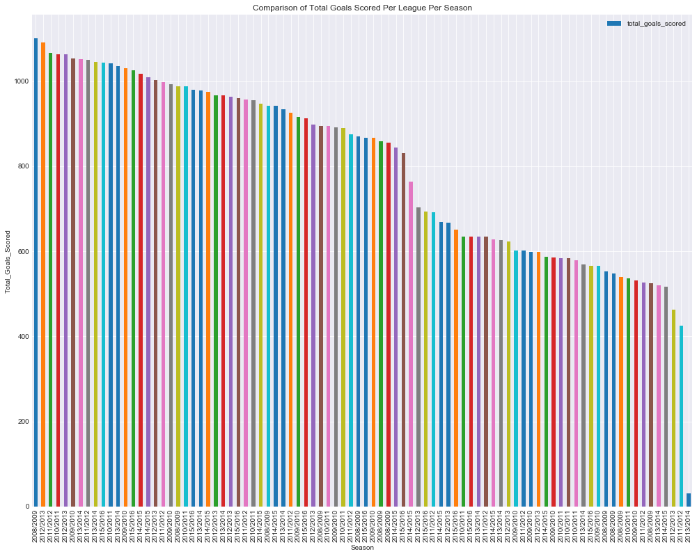

```python
total_goals_df.plot(x='season', y='total_goals_scored', kind='bar',
                    figsize=(17,13), legend=True);

# labeling my axes and title
plt.xlabel('Season')
plt.ylabel('Total_Goals_Scored')
plt.title('Comparison of Total Goals Scored Per League Per Season')
```

Wow, that's really busy and hard to read. Let's break up this data a bit by filtering our data for each year or season.

```python
# First let's confirm total goals scored are tallied for each league per year(season)
total_goals_df['season'].value_counts()
```

```
2010/2011    11
2015/2016    11
2009/2010    11
2012/2013    11
2014/2015    11
2013/2014    11
2011/2012    11
2008/2009    11
Name: season, dtype: int64
```

```python
# Using Pandas' 'query' function to compare all European league goal tallys within the same season (2008/2009).
tg_m_0809_df = total_goals_df.query("season == '2008/2009'")

tg_m_0809_df
```

|  | league_id | league | season | total_home_goals_scored | total_away_goals_scored | total_goals_scored |
| --- | --- | --- | --- | --- | --- | --- |
| 0 | 21518 | Spain LIGA BBVA | 2008/2009 | 631 | 470 | 1101 |
| 19 | 10257 | Italy Serie A | 2008/2009 | 578 | 410 | 988 |
| 31 | 1729 | England Premier League | 2008/2009 | 532 | 410 | 942 |
| 38 | 7809 | Germany 1. Bundesliga | 2008/2009 | 520 | 374 | 894 |
| 43 | 13274 | Netherlands Eredivisie | 2008/2009 | 524 | 346 | 870 |
| 46 | 4769 | France Ligue 1 | 2008/2009 | 489 | 369 | 858 |
| 47 | 1 | Belgium Jupiler League | 2008/2009 | 499 | 356 | 855 |
| 76 | 17642 | Portugal Liga ZON Sagres | 2008/2009 | 296 | 256 | 552 |
| 77 | 19694 | Scotland Premier League | 2008/2009 | 301 | 247 | 548 |
| 78 | 24558 | Switzerland Super League | 2008/2009 | 316 | 224 | 540 |
| 82 | 15722 | Poland Ekstraklasa | 2008/2009 | 321 | 203 | 524 |

```python
# setting my index to league names, that way when I plot it, I dont have to distiguish my xtick labels
tg_m_0809_df.set_index('league', inplace=True)
```

```python
tg_m_0809_df
```

| league | league_id | season | total_home_goals_scored | total_away_goals_scored | total_goals_scored |
| --- | --- | --- | --- | --- | --- |
| Spain LIGA BBVA | 21518 | 2008/2009 | 631 | 470 | 1101 |
| Italy Serie A | 10257 | 2008/2009 | 578 | 410 | 988 |
| England Premier League | 1729 | 2008/2009 | 532 | 410 | 942 |
| Germany 1. Bundesliga | 7809 | 2008/2009 | 520 | 374 | 894 |
| Netherlands Eredivisie | 13274 | 2008/2009 | 524 | 346 | 870 |
| France Ligue 1 | 4769 | 2008/2009 | 489 | 369 | 858 |
| Belgium Jupiler League | 1 | 2008/2009 | 499 | 356 | 855 |
| Portugal Liga ZON Sagres | 17642 | 2008/2009 | 296 | 256 | 552 |
| Scotland Premier League | 19694 | 2008/2009 | 301 | 247 | 548 |
| Switzerland Super League | 24558 | 2008/2009 | 316 | 224 | 540 |
| Poland Ekstraklasa | 15722 | 2008/2009 | 321 | 203 | 524 |

```python
# in order to get a list of the leagues, I'll need to reset my index here
tg_m_0809_df.reset_index(inplace=True)
```

Let's take a closer look at this data. I'd like to find out the percentage of goals each league has to total goals scored for the 11 European leagues combined during the 2008/2009 season. (I'll plot this for 3 seasons to save space.) To do this I would like to create a pie chart to show the percentages.

```python
# creating an array of the total goals scored column
tg_scd_0809 = np.array(tg_m_0809_df['total_goals_scored'])
```

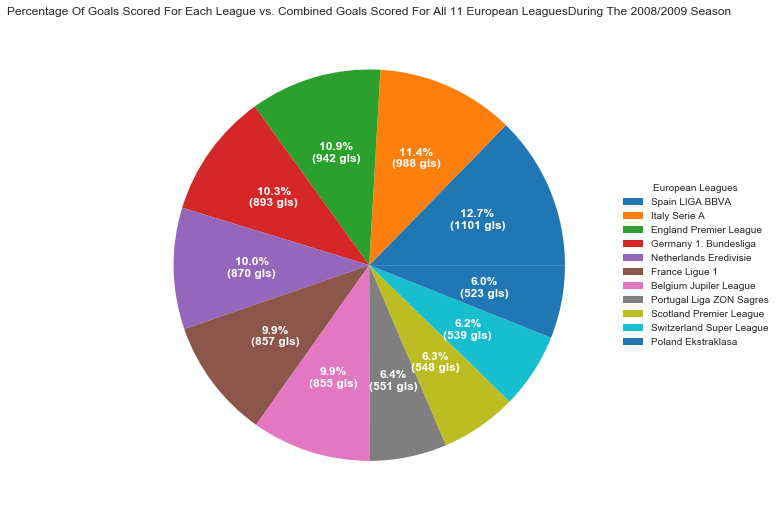

```python
tg_scd_0809_fig, ax = plt.subplots(figsize=(17,9), subplot_kw=dict(aspect='equal'))

data = tg_scd_0809

league_lst = list(tg_m_0809_df['league'])

def func(pct, allvals):
    absolute = int(pct/100.*np.sum(allvals))
    return "{:.1f}%\n({:d} gls)".format(pct, absolute)

wedges, texts, autotexts = ax.pie(data, autopct=lambda pct: func(pct, data), textprops=dict(color='w'))

ax.legend(wedges, league_lst, title='European Leagues', loc='center left', bbox_to_anchor=(1, 0, 0.5, 1))

plt.setp(autotexts, size=12, weight='bold')

ax.set_title('Percentage Of Goals Scored For Each League vs. Combined Goals Scored For All 11 European Leagues' \
             'During The 2008/2009 Season')
plt.show()
```

```python
tg_m_0809_df.describe()
```

|  | league_id | total_home_goals_scored | total_away_goals_scored | total_goals_scored |
| --- | --- | --- | --- | --- |
| count | 11.000000 | 11.000000 | 11.000000 | 11.000000 |
| mean | 12452.090909 | 455.181818 | 333.181818 | 788.363636 |
| std | 8215.308472 | 122.631821 | 87.411462 | 208.213483 |
| min | 1.000000 | 296.000000 | 203.000000 | 524.000000 |
| 25% | 6289.000000 | 318.500000 | 251.500000 | 550.000000 |
| 50% | 13274.000000 | 499.000000 | 356.000000 | 858.000000 |
| 75% | 18668.000000 | 528.000000 | 392.000000 | 918.000000 |
| max | 24558.000000 | 631.000000 | 470.000000 | 1101.000000 |

I chose to run the '.describe()' method on the data frame because it can be a great indicator and provide window access to valuable insight within the data. You will find running the describe method to be a common theme throughout this report. I'll do my due diligence by not only acknowledging it but also mentioning that here and for future analysis within this report important ideas for exploration were spawned. I'll do my best to make note of as many occurrences as I can remember. By taking a look at the '''.describe()''' method run on our total goals manipulated 2008/2009 data frame, it has immediately generated more questions than my initial intentions. I had to be very careful however, because each discovery for a new approach to analysis could, if you're not careful, lead you down a rabbit hole.

For example, I'd be interested to find out which leagues, consistantly, year in, year out, were amoung the top 75% for total goals scored within the league, but also top 75% for home goals scored and away goals scored. That has to be a short list right? ... with so many variables to consider? We'll see, if not on this go around, definitely on another.

```python
# setting my index back to league so my xticks are labeled
tg_m_0809_df.set_index('league', inplace=True)
```

```
Text(0,0.5,'Total_Goals_Scored')
```

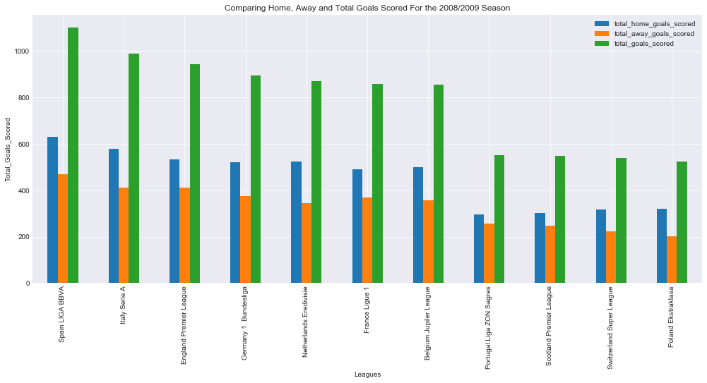

```python
tg_m_0809_df[['total_home_goals_scored',
              'total_away_goals_scored',
              'total_goals_scored']].plot(kind='bar', subplots=False, figsize=(17, 7));

# setting my labels
plt.title('Comparing Home, Away and Total Goals Scored For the 2008/2009 Season')
plt.xlabel('Leagues')
plt.ylabel('Total_Goals_Scored')
```

Now, don't get me wrong here, La Liga is my favorite league, hands down. To me, they play the game the way it should be played, passing and moving, creativity and ingenuity rule the pitch, not strength, speed, and physicality, like the English Premier League. But it surprises me that even in its monotony (at times) the possession game still rang true with the most goals. This statistic is hypocritical in a sense because the biggest argument about possession futbol is that there aren't enough goals, not enough excitement for the fans, but this seems to prove otherwise. It will be interesting to see the results for subsequent years to come.

```python
# Using Pandas' 'query' function to compare all European league goal tallys within
# the same season (2009/2010).
tg_m_0910_df = total_goals_df.query("season == '2009/2010'")
```

```python
# setting my index to league names, that way when I plot it, I dont have to distiguish
# my xtick labels
tg_m_0910_df.set_index('league', inplace=True)
```

```python
tg_m_0910_df
```

| league | league_id | season | total_home_goals_scored | total_away_goals_scored | total_goals_scored |
| --- | --- | --- | --- | --- | --- |
| England Premier League | 1729 | 2009/2010 | 645 | 408 | 1053 |
| Spain LIGA BBVA | 21518 | 2009/2010 | 608 | 423 | 1031 |
| Italy Serie A | 10257 | 2009/2010 | 586 | 406 | 992 |
| France Ligue 1 | 4769 | 2009/2010 | 528 | 388 | 916 |
| Netherlands Eredivisie | 13274 | 2009/2010 | 528 | 364 | 892 |
| Germany 1. Bundesliga | 7809 | 2009/2010 | 463 | 403 | 866 |
| Portugal Liga ZON Sagres | 17642 | 2009/2010 | 333 | 268 | 601 |
| Switzerland Super League | 24558 | 2009/2010 | 359 | 240 | 599 |
| Scotland Premier League | 19694 | 2009/2010 | 321 | 264 | 585 |
| Belgium Jupiler League | 1 | 2009/2010 | 308 | 257 | 565 |
| Poland Ekstraklasa | 15722 | 2009/2010 | 299 | 233 | 532 |

```python
# in order to get a list of the leagues, I'll need to reset my index here
tg_m_0910_df.reset_index(inplace=True)
```

```python
# creating an array of the total goals scored column
tg_scd_0910 = np.array(tg_m_0910_df['total_goals_scored'])
```

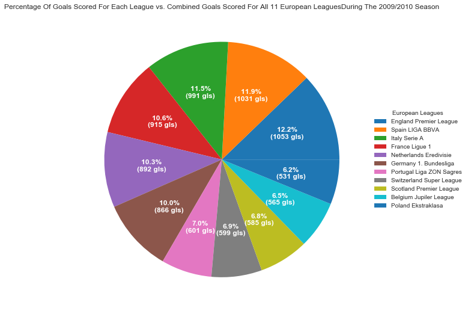

```python
tg_scd_0910_fig, ax = plt.subplots(figsize=(17,9), subplot_kw=dict(aspect='equal'))

data = tg_scd_0910

league_lst = list(tg_m_0910_df['league'])

def func(pct, allvals):
    absolute = int(pct/100.*np.sum(allvals))
    return "{:.1f}%\n({:d} gls)".format(pct, absolute)

wedges, texts, autotexts = ax.pie(data, autopct=lambda pct: func(pct, data), textprops=dict(color='w'))

ax.legend(wedges, league_lst, title='European Leagues', loc='center left', bbox_to_anchor=(1, 0, 0.5, 1))

plt.setp(autotexts, size=12, weight='bold')

ax.set_title('Percentage Of Goals Scored For Each League vs. Combined Goals Scored For All 11 European Leagues' \
             'During The 2009/2010 Season')
plt.show()
```

```python
tg_m_0910_df.describe()
```

|  | league_id | total_home_goals_scored | total_away_goals_scored | total_goals_scored |
| --- | --- | --- | --- | --- |
| count | 11.000000 | 11.000000 | 11.000000 | 11.000000 |
| mean | 12452.090909 | 452.545455 | 332.181818 | 784.727273 |
| std | 8215.308472 | 132.410999 | 78.322178 | 207.658417 |
| min | 1.000000 | 299.000000 | 233.000000 | 532.000000 |
| 25% | 6289.000000 | 327.000000 | 260.500000 | 592.000000 |
| 50% | 13274.000000 | 463.000000 | 364.000000 | 866.000000 |
| 75% | 18668.000000 | 557.000000 | 404.500000 | 954.000000 |
| max | 24558.000000 | 645.000000 | 423.000000 | 1053.000000 |

```python
# setting my index back to league names, that way when I plot it, I dont have to distiguish my xtick labels
tg_m_0910_df.set_index('league', inplace=True)
```

```
Text(0,0.5,'Total_Goals_Scored')
```

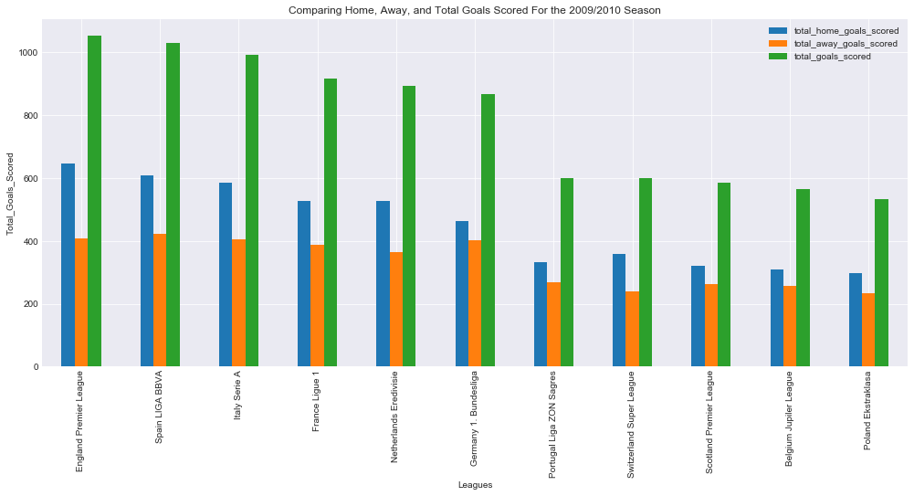

```python
tg_m_0910_df[['total_home_goals_scored',
              'total_away_goals_scored',
              'total_goals_scored']].plot(kind='bar', subplots=False, figsize=(17, 7));

# setting my labels
plt.title('Comparing Home, Away, and Total Goals Scored For the 2009/2010 Season')
plt.xlabel('Leagues')
plt.ylabel('Total_Goals_Scored')
```

Ahh, ok, this will satisfy the haters of La Liga. English Premier League on top, although not by much, netting a total of 1053 goals, 645 scored by home teams, and 408 by away teams. Spain's La Liga comes in a close second here scoring a total of 1031 goals, 608 scored by home teams and 423 by away teams. On a side note, in fact, a little silver bullet for La Liga fans here, is that even though they may not have scored the most total goals for the 2009/2010 season, the leagues' away teams however, outperformed their counterparts of the English Premier League by scoring more away goals. That's a nice stat I'll keep in my back pocket acutally, and I have the data to prove it, Ha!

A consistent trend I have however began to notice and given my experience with the game, had obviously assumed(but was curious to confirm), is that home teams generally score more goals, given the support of their fans. It just goes to show that this is truly an emotionally fueled game, as the players, supported by their fans, seem to feed off of that energy and produce better results.

The same 5 leagues are at the bottom although in slightly different order than the 2008/2009 season. Still again, we have Portugal Liga ZON Sagres, Switzerland Super League, Scotland Premier League, Belgium Jupiler League and the Poland Ekstraklasa. What is interesting to see though, just at first glance is that the lower 5 leagues seem to have less discrepancy in goals scored away from home, vs. the top tier leagues. I wonder what that variance or lack there of would be due to? That may be something I might want to tackle later in my analysis.

```python
# Using Pandas' 'query' function to compare all European league goal tallys within the
# same season (2010/2011).
tg_m_1011_df = total_goals_df.query("season == '2010/2011'")
```

```python
# setting my index to league names
tg_m_1011_df.set_index('league', inplace=True)
```

```python
tg_m_1011_df
```

| league | league_id | season | total_home_goals_scored | total_away_goals_scored | total_goals_scored |
| --- | --- | --- | --- | --- | --- |
| England Premier League | 1729 | 2010/2011 | 617 | 446 | 1063 |
| Spain LIGA BBVA | 21518 | 2010/2011 | 622 | 420 | 1042 |
| Netherlands Eredivisie | 13274 | 2010/2011 | 595 | 392 | 987 |
| Italy Serie A | 10257 | 2010/2011 | 544 | 411 | 955 |
| Germany 1. Bundesliga | 7809 | 2010/2011 | 504 | 390 | 894 |
| France Ligue 1 | 4769 | 2010/2011 | 510 | 380 | 890 |
| Belgium Jupiler League | 1 | 2010/2011 | 382 | 253 | 635 |
| Portugal Liga ZON Sagres | 17642 | 2010/2011 | 315 | 269 | 584 |
| Scotland Premier League | 19694 | 2010/2011 | 315 | 269 | 584 |
| Poland Ekstraklasa | 15722 | 2010/2011 | 361 | 217 | 578 |
| Switzerland Super League | 24558 | 2010/2011 | 283 | 254 | 537 |

```python
# in order to get a list of the leagues, I'll need to reset my index here
tg_m_1011_df.reset_index(inplace=True)
```

```python
# creating an array of the total goals scored column
tg_scd_1011 = np.array(tg_m_1011_df['total_goals_scored'])
```

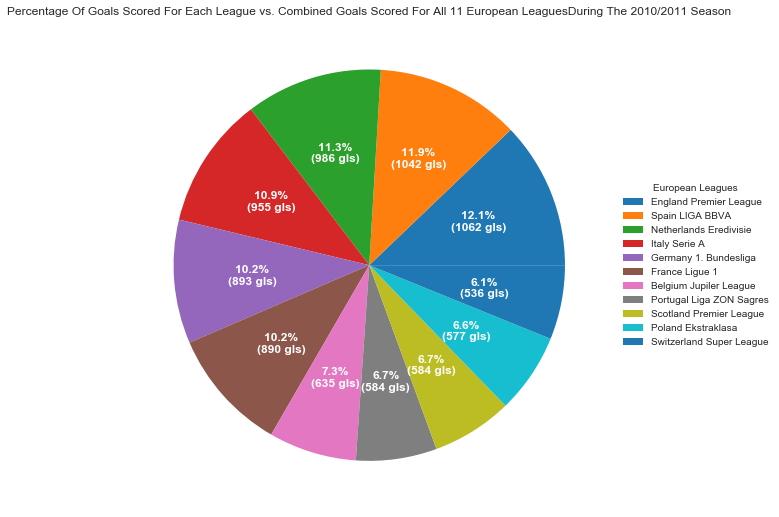

```python
tg_scd_1011_fig, ax = plt.subplots(figsize=(17,9), subplot_kw=dict(aspect='equal'))

data = tg_scd_1011

league_lst = list(tg_m_1011_df['league'])

def func(pct, allvals):
    absolute = int(pct/100.*np.sum(allvals))
    return "{:.1f}%\n({:d} gls)".format(pct, absolute)

wedges, texts, autotexts = ax.pie(data, autopct=lambda pct: func(pct, data), textprops=dict(color='w'))

ax.legend(wedges, league_lst, title='European Leagues', loc='center left', bbox_to_anchor=(1, 0, 0.5, 1))

plt.setp(autotexts, size=12, weight='bold')

ax.set_title('Percentage Of Goals Scored For Each League vs. Combined Goals Scored For All 11 European Leagues' \
             'During The 2010/2011 Season')
plt.show()
```

```python
tg_m_1011_df.describe()
```

|  | league_id | total_home_goals_scored | total_away_goals_scored | total_goals_scored |
| --- | --- | --- | --- | --- |
| count | 11.000000 | 11.000000 | 11.000000 | 11.000000 |
| mean | 12452.090909 | 458.909091 | 336.454545 | 795.363636 |
| std | 8215.308472 | 130.330698 | 83.377891 | 210.337002 |
| min | 1.000000 | 283.000000 | 217.000000 | 537.000000 |
| 25% | 6289.000000 | 338.000000 | 261.500000 | 584.000000 |
| 50% | 13274.000000 | 504.000000 | 380.000000 | 890.000000 |
| 75% | 18668.000000 | 569.500000 | 401.500000 | 971.000000 |
| max | 24558.000000 | 622.000000 | 446.000000 | 1063.000000 |

```python
# setting my index to league names
tg_m_1011_df.set_index('league', inplace=True)
```

```
Text(0,0.5,'Total_Goals_Scored')
```

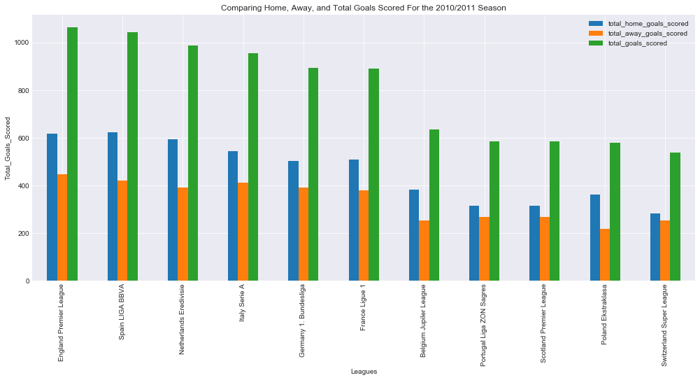

```python
tg_m_1011_df[['total_home_goals_scored',
              'total_away_goals_scored',
              'total_goals_scored']].plot(kind='bar', subplots=False, figsize=(17, 7));

# setting my labels
plt.title('Comparing Home, Away, and Total Goals Scored For the 2010/2011 Season')
plt.xlabel('Leagues')
plt.ylabel('Total_Goals_Scored')
```

England's English Premier League is again on top scoring a total of 1063 goals, 617 by home teams and 446 by away teams. And again, we have Spain's La Liga coming in a close second, scoring a total of 1042 goals, 622 by home teams and 420 by away teams. Jumping up however a couple of spots to the third most goals in 2010/2011 is the Netherland's Erevidisie amassing a total of 987 goals, with 595 goals tallied by home teams and 392 by away teams. Nothing too surprising here either, although I will be honest: I was hoping to find a league where away goals were equal to or more than home tallys but this has not seemed to be the case in any years of analysis so far. I don't expect to find one either but it would be interesting to explore.

```python
# Using Pandas' 'query' function to compare all European league goal tallys within the
# same season (2011/2012).
tg_m_1112_df = total_goals_df.query("season == '2011/2012'")
```

```python
tg_m_1112_df.set_index('league', inplace=True)
```

```python
tg_m_1112_df.describe()
```

|  | league_id | total_home_goals_scored | total_away_goals_scored | total_goals_scored |
| --- | --- | --- | --- | --- |
| count | 11.000000 | 11.000000 | 11.000000 | 11.000000 |
| mean | 12452.090909 | 460.363636 | 334.818182 | 795.181818 |
| std | 8215.308472 | 140.187212 | 88.102007 | 226.183031 |
| min | 1.000000 | 235.000000 | 190.000000 | 425.000000 |
| 25% | 6289.000000 | 337.000000 | 272.500000 | 617.500000 |
| 50% | 13274.000000 | 508.000000 | 367.000000 | 875.000000 |
| 75% | 18668.000000 | 572.500000 | 404.000000 | 976.500000 |
| max | 24558.000000 | 638.000000 | 462.000000 | 1066.000000 |

```
Text(0,0.5,'Total_Goals_Scored')
```

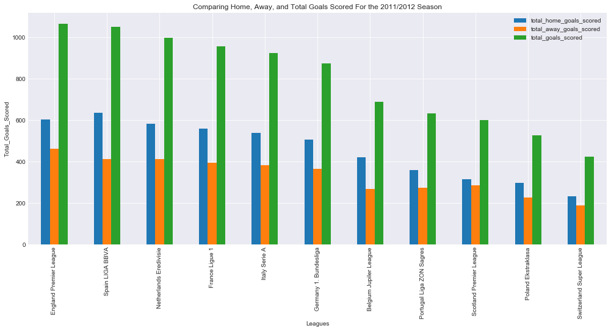

```python
tg_m_1112_df[['total_home_goals_scored',
              'total_away_goals_scored',
              'total_goals_scored']].plot(kind='bar', subplots=False, figsize=(17, 7));

# setting my labels
plt.title('Comparing Home, Away, and Total Goals Scored For the 2011/2012 Season')
plt.xlabel('Leagues')
plt.ylabel('Total_Goals_Scored')
```

Im starting to, unfortunately, notice a trend here. The top two leagues in terms of total goals scored are the same two, with the English Premier League on top again, totalling 1066 goals, 604 scored by home teams and 462 by away teams. Spain's La Liga in a close second(again) with a total of 1050 goals tallied, 638 by home teams and 412 by away teams. Interesting here though is that La Liga's home teams scored more goals than England's Premier League, but the vise versa now rings true. Engaland's away teams have tallied more goals than Spain's La Liga. I can't wait to delve into the types of teams and their styles of play that make up their respective leagues. It'll be interesting to see if top leagues have similar team attributes. I hope there's time.

```python
# Using Pandas' 'query' function to compare all European league goal tallys within the
# same season (2012/2013).
tg_m_1213_df = total_goals_df.query("season == '2012/2013'")
```

```python
tg_m_1213_df.set_index('league', inplace=True)
```

```python
tg_m_1213_df.describe()
```

|  | league_id | total_home_goals_scored | total_away_goals_scored | total_goals_scored |
| --- | --- | --- | --- | --- |
| count | 11.000000 | 11.000000 | 11.000000 | 11.000000 |
| mean | 12452.090909 | 459.363636 | 362.363636 | 821.727273 |
| std | 8215.308472 | 128.499239 | 89.696458 | 216.270706 |
| min | 1.000000 | 272.000000 | 190.000000 | 462.000000 |
| 25% | 6289.000000 | 349.000000 | 296.000000 | 645.000000 |
| 50% | 13274.000000 | 487.000000 | 409.000000 | 898.000000 |
| 75% | 18668.000000 | 563.000000 | 429.500000 | 985.000000 |
| max | 24558.000000 | 641.000000 | 471.000000 | 1091.000000 |

```
Text(0,0.5,'Total_Goals_Scored')
```

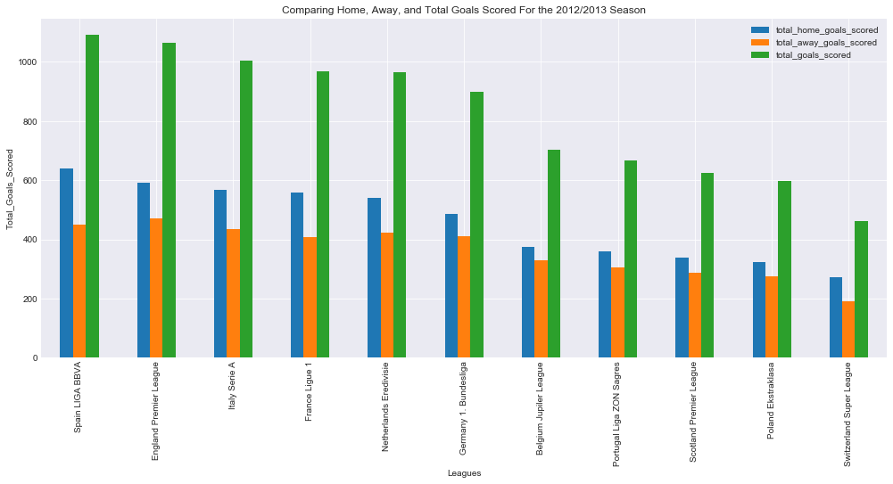

```python
tg_m_1213_df[['total_home_goals_scored',
              'total_away_goals_scored',
              'total_goals_scored']].plot(kind='bar', subplots=False, figsize=(17, 7));

# setting my labels
plt.title('Comparing Home, Away, and Total Goals Scored For the 2012/2013 Season')
plt.xlabel('Leagues')
plt.ylabel('Total_Goals_Scored')
```

It begs to wonder, is the success of these Bundesliga teams due to just a few starlets in a crowded league of mediocrity, which in essence validates the results we're finding here ( 898 total goals, 487 scored by home teams and 411 by away teams), or is the league's persona (like that of the Italian Serie A from the early 2000's) and commitment to defence manifesting itself in the leagues inability to score mulitiple goals a game?

The amount of analysis that can be done on this dataset truly is limitless.

```python
# Using Pandas' 'query' function to compare all European league goal tallys within the
# same season (2013/2014).
tg_m_1314_df = total_goals_df.query("season == '2013/2014'")
```

```python
tg_m_1314_df.set_index('league', inplace=True)
```

```python
tg_m_1314_df.describe()
```

|  | league_id | total_home_goals_scored | total_away_goals_scored | total_goals_scored |
| --- | --- | --- | --- | --- |
| count | 11.000000 | 11.000000 | 11.000000 | 11.000000 |
| mean | 12452.090909 | 435.181818 | 327.454545 | 762.636364 |
| std | 8215.308472 | 184.859849 | 135.848713 | 319.867558 |
| min | 1.000000 | 18.000000 | 12.000000 | 30.000000 |
| 25% | 6289.000000 | 332.000000 | 256.000000 | 597.500000 |
| 50% | 13274.000000 | 535.000000 | 395.000000 | 933.000000 |
| 75% | 18668.000000 | 576.000000 | 428.500000 | 1006.500000 |
| max | 24558.000000 | 620.000000 | 454.000000 | 1052.000000 |

```
Text(0,0.5,'Total_Goals_Scored')
```

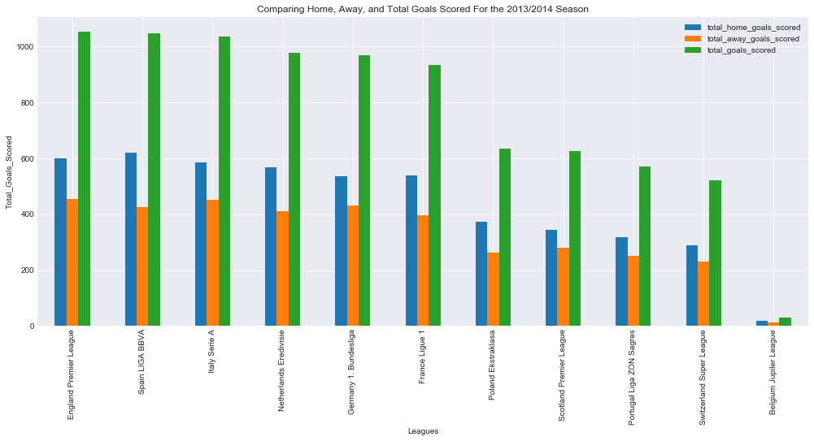

```python
tg_m_1314_df[['total_home_goals_scored',
              'total_away_goals_scored',
              'total_goals_scored']].plot(kind='bar', subplots=False, figsize=(17, 7));

# setting my labels
plt.title('Comparing Home, Away, and Total Goals Scored For the 2013/2014 Season')
plt.xlabel('Leagues')
plt.ylabel('Total_Goals_Scored')
```

Whoa. That's odd. The Belgium Jupiler League has like no goals tallied at all, ok very few; 18 home goals scored, 12 away for a total of 30 goals for the 2013/2014 season, which seems highly unlikely. The fewest we've seen yet in our analysis, which makes me wonder if its an outlier and would need to be removed from the set. I guess for this analysis its relevant, but for say comparing the variance between attributes within each league, it may be best to get rid of this data.

```python
# Using Pandas' 'query' function to compare all European league goal tallys within the same season (2014/2015).
tg_m_1415_df = total_goals_df.query("season == '2014/2015'")
```

```python
tg_m_1415_df.set_index('league', inplace=True)
```

```python
tg_m_1415_df.describe()
```

|  | league_id | total_home_goals_scored | total_away_goals_scored | total_goals_scored |
| --- | --- | --- | --- | --- |
| count | 11.000000 | 11.000000 | 11.000000 | 11.000000 |
| mean | 12452.090909 | 459.545455 | 349.272727 | 808.818182 |
| std | 8215.308472 | 104.653107 | 80.214825 | 183.965115 |
| min | 1.000000 | 289.000000 | 228.000000 | 517.000000 |
| 25% | 6289.000000 | 370.000000 | 278.000000 | 648.000000 |
| 50% | 13274.000000 | 486.000000 | 357.000000 | 843.000000 |
| 75% | 18668.000000 | 548.000000 | 419.500000 | 961.000000 |
| max | 24558.000000 | 584.000000 | 450.000000 | 1018.000000 |

```
Text(0,0.5,'Total_Goals_Scored')
```

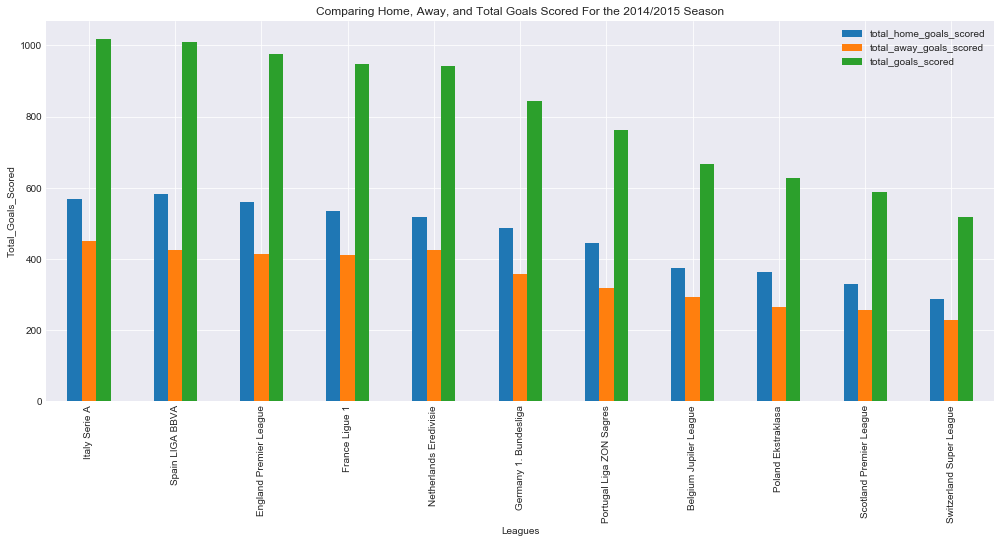

```python
tg_m_1415_df[['total_home_goals_scored',
              'total_away_goals_scored',
              'total_goals_scored']].plot(kind='bar', subplots=False, figsize=(17, 7));

# setting my labels
plt.title('Comparing Home, Away, and Total Goals Scored For the 2014/2015 Season')
plt.xlabel('Leagues')
plt.ylabel('Total_Goals_Scored')
```

```python
# Using Pandas' 'query' function to compare all European league goal tallys within the same season (2015/2016).
tg_m_1516_df = total_goals_df.query("season == '2015/2016'")
```

```python
tg_m_1516_df.set_index('league', inplace=True)
```

```python
tg_m_1516_df.describe()
```

|  | league_id | total_home_goals_scored | total_away_goals_scored | total_goals_scored |
| --- | --- | --- | --- | --- |
| count | 11.000000 | 11.000000 | 11.000000 | 11.000000 |
| mean | 12452.090909 | 466.818182 | 366.090909 | 832.909091 |
| std | 8215.308472 | 102.267119 | 70.106283 | 170.126691 |
| min | 1.000000 | 321.000000 | 245.000000 | 566.000000 |
| 25% | 6289.000000 | 372.500000 | 300.500000 | 672.000000 |
| 50% | 13274.000000 | 479.000000 | 387.000000 | 866.000000 |
| 75% | 18668.000000 | 552.500000 | 417.000000 | 969.500000 |
| max | 24558.000000 | 615.000000 | 459.000000 | 1043.000000 |

```
Text(0,0.5,'Total_Goals_Scored')
```

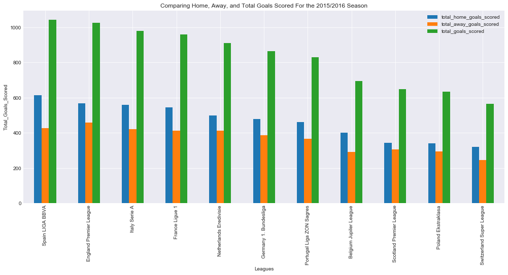

```python
tg_m_1516_df[['total_home_goals_scored',
              'total_away_goals_scored',
              'total_goals_scored']].plot(kind='bar', subplots=False, figsize=(17, 7));

# setting my labels
plt.title('Comparing Home, Away, and Total Goals Scored For the 2015/2016 Season')
plt.xlabel('Leagues')
plt.ylabel('Total_Goals_Scored')
```

And finally, for the 2015/2016 season, it looks like Spain's La Liga topped England's Premier League with 1043 goals to 1026 respectively. La Liga may have had the edge in goals scored by home teams, but it looks as though England's road warriors came to play, ammassing a whopping 459 goals to La Liga's 428 scored by away teams.

I'd like to take a further look at the data here by looking at the percentage change in goals scored by league by season. It would be interesting to see if any trends exist when looking at the data from this perspective. I'll save that for future analysis.

```python
tg_m_1112_df
```

| league | league_id | season | total_home_goals_scored | total_away_goals_scored | total_goals_scored |
| --- | --- | --- | --- | --- | --- |
| England Premier League | 1729 | 2011/2012 | 604 | 462 | 1066 |
| Spain LIGA BBVA | 21518 | 2011/2012 | 638 | 412 | 1050 |
| Netherlands Eredivisie | 13274 | 2011/2012 | 585 | 412 | 997 |
| France Ligue 1 | 4769 | 2011/2012 | 560 | 396 | 956 |
| Italy Serie A | 10257 | 2011/2012 | 541 | 384 | 925 |
| Germany 1. Bundesliga | 7809 | 2011/2012 | 508 | 367 | 875 |
| Belgium Jupiler League | 1 | 2011/2012 | 421 | 270 | 691 |
| Portugal Liga ZON Sagres | 17642 | 2011/2012 | 359 | 275 | 634 |
| Scotland Premier League | 19694 | 2011/2012 | 315 | 286 | 601 |
| Poland Ekstraklasa | 15722 | 2011/2012 | 298 | 229 | 527 |
| Switzerland Super League | 24558 | 2011/2012 | 235 | 190 | 425 |

```python
# defining which column I'd like to concatenate from these data frames
column_name = ['total_goals_scored']

cmbd_tg_scd_df = pd.concat([tg_m_0809_df[column_name], tg_m_0910_df[column_name], tg_m_1011_df[column_name],
                            tg_m_1112_df[column_name], tg_m_1213_df[column_name], tg_m_1314_df[column_name],
                            tg_m_1415_df[column_name], tg_m_1516_df[column_name]], axis=1,
                            keys=['2008/2009', '2009/2010', '2011/2012', '2012/2013', '2013/2014', '2014/2015',
                                 '2015/2016'])
```

```python
cmbd_tg_scd_df = cmbd_tg_scd_df.transpose()
```

```python
cmbd_tg_scd_df.reset_index(inplace=True)
```

```python
cmbd_tg_scd_df
```

|  |  | Belgium Jupiler League | England Premier League | France Ligue 1 | Germany 1. Bundesliga | Italy Serie A | Netherlands Eredivisie | Poland Ekstraklasa | Portugal Liga ZON Sagres | Scotland Premier League | Spain LIGA BBVA | Switzerland Super League |
| --- | --- | --- | --- | --- | --- | --- | --- | --- | --- | --- | --- | --- |
| 2008/2009 | total_goals_scored | 855 | 942 | 858 | 894 | 988 | 870 | 524 | 552 | 548 | 1101 | 540 |
| 2009/2010 | total_goals_scored | 565 | 1053 | 916 | 866 | 992 | 892 | 532 | 601 | 585 | 1031 | 599 |
| 2011/2012 | total_goals_scored | 635 | 1063 | 890 | 894 | 955 | 987 | 578 | 584 | 584 | 1042 | 537 |
| 2012/2013 | total_goals_scored | 691 | 1066 | 956 | 875 | 925 | 997 | 527 | 634 | 601 | 1050 | 425 |
| 2013/2014 | total_goals_scored | 703 | 1063 | 967 | 898 | 1003 | 964 | 598 | 667 | 623 | 1091 | 462 |
| 2014/2015 | total_goals_scored | 30 | 1052 | 933 | 967 | 1035 | 978 | 634 | 569 | 626 | 1045 | 520 |
| 2015/2016 | total_goals_scored | 668 | 975 | 947 | 843 | 1018 | 942 | 628 | 763 | 587 | 1009 | 517 |

```python
cmbd_tg_scd_df.reset_index(inplace=True)
```

```python
cmbd_tg_scd_df.rename(columns={'level_0':'season'}, inplace=True)
```

```python
cmbd_tg_scd_df
```

|  | season | Belgium Jupiler League | England Premier League | France Ligue 1 | Germany 1. Bundesliga | Italy Serie A | Netherlands Eredivisie | Poland Ekstraklasa | Portugal Liga ZON Sagres | Scotland Premier League | Spain LIGA BBVA | Switzerland Super League |
| --- | --- | --- | --- | --- | --- | --- | --- | --- | --- | --- | --- | --- |
| 0 | 2008/2009 | 855 | 942 | 858 | 894 | 988 | 870 | 524 | 552 | 548 | 1101 | 540 |
| 1 | 2009/2010 | 565 | 1053 | 916 | 866 | 992 | 892 | 532 | 601 | 585 | 1031 | 599 |
| 2 | 2011/2012 | 635 | 1063 | 890 | 894 | 955 | 987 | 578 | 584 | 584 | 1042 | 537 |
| 3 | 2012/2013 | 691 | 1066 | 956 | 875 | 925 | 997 | 527 | 634 | 601 | 1050 | 425 |
| 4 | 2013/2014 | 703 | 1063 | 967 | 898 | 1003 | 964 | 598 | 667 | 623 | 1091 | 462 |
| 5 | 2014/2015 | 30 | 1052 | 933 | 967 | 1035 | 978 | 634 | 569 | 626 | 1045 | 520 |
| 6 | 2015/2016 | 668 | 975 | 947 | 843 | 1018 | 942 | 628 | 763 | 587 | 1009 | 517 |

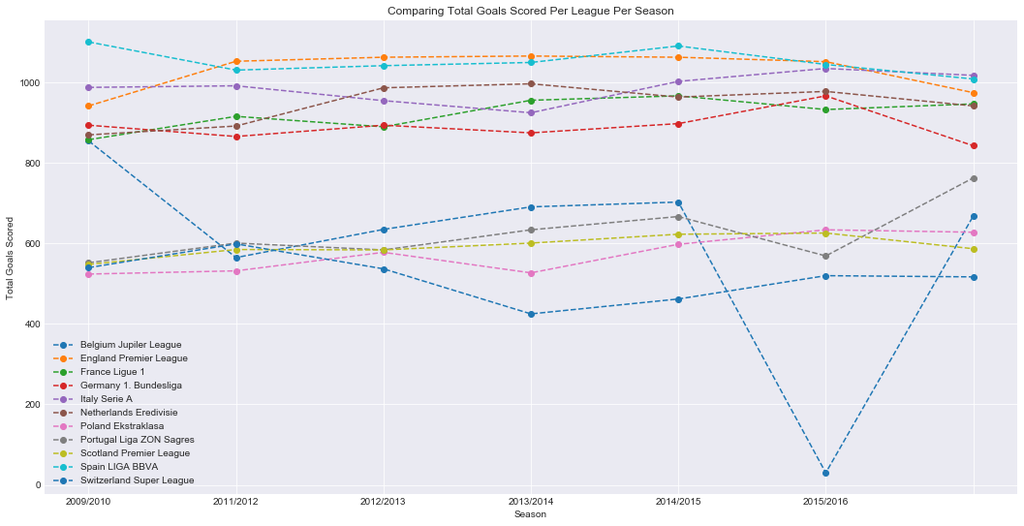

```python
# Setting my labels for the graph
labels = list(cmbd_tg_scd_df['season'])

# Creating a matplotlib.axes.AxesSubplot object
cmbd_tg_fig, ax = plt.subplots(figsize=(18,9))

# Setting the labels on my matplotlib object
ax.set_xticklabels(labels)
ax.set_xlabel('Season')
ax.set_ylabel('Total Goals Scored')

cmbd_tg_scd_df[['Belgium Jupiler League', 'England Premier League', 'France Ligue 1',
                'Germany 1. Bundesliga', 'Italy Serie A', 'Netherlands Eredivisie',
                'Poland Ekstraklasa', 'Portugal Liga ZON Sagres', 'Scotland Premier League',
                'Spain LIGA BBVA', 'Switzerland Super League']].plot(kind='line',ax=ax,
                                                                     title="Comparing Total Goals Scored Per League Per Season", legend=True, style='--', marker='o');
```

**EXPLORING THE TEAM ATTRIBUTES DATAFRAME**

```python
# I need to replace the NaN/Null values within the team_attr_df 'buildUpPlayDribbling' column we saw earlier in
# our brief look at the data. Let's find the mean.
team_attr_df['buildUpPlayDribbling'].mean()
```

```
48.60450819672131
```

```python
# replacing all the NaN/Null values within the 'buildUpPlayDribbling' column with the mean from that column
team_attr_df = team_attr_df.fillna(team_attr_df['buildUpPlayDribbling'].mean())
```

```python
# creating a new team ratings data frame so as not to overwrite the existing team_attr_df when conducting my analysis.
# I also ommitted the 'class' columns for each team attribute as they were strings and not helpful to my analysis
team_rating_df = pd.DataFrame(team_attr_df[['team_name', 'date', 'buildUpPlaySpeed', 'buildUpPlayDribbling',
                                           'buildUpPlayPassing', 'chanceCreationPassing', 'chanceCreationCrossing',
                                           'chanceCreationShooting', 'defencePressure', 'defenceAggression',
                                           'defenceTeamWidth']])
```

```python
# using a lambda expression to create a column 'overall_team_rating' which is just the sum of each team attribute
# divided by the number of team attributes
team_rating_df['overall_team_rating'] = team_attr_df.apply(lambda row: ((row['buildUpPlaySpeed'] + row['buildUpPlayDribbling']
                                                              + row['buildUpPlayPassing'] + row['chanceCreationPassing']
                                                              + row['chanceCreationCrossing'] + row['chanceCreationShooting']
                                                              + row['defencePressure'] + row['defenceAggression']
                                                              + row['defenceTeamWidth']) / 9), axis=1)
```

```python
team_rating_df.describe()
```

|  | buildUpPlaySpeed | buildUpPlayDribbling | buildUpPlayPassing | chanceCreationPassing | chanceCreationCrossing | chanceCreationShooting | defencePressure | defenceAggression | defenceTeamWidth | overall_team_rating |
| --- | --- | --- | --- | --- | --- | --- | --- | --- | --- | --- |
| count | 1457.000000 | 1457.000000 | 1457.000000 | 1457.000000 | 1457.000000 | 1457.000000 | 1457.000000 | 1457.000000 | 1457.000000 | 1457.000000 |
| mean | 52.463967 | 48.604508 | 48.489362 | 52.166781 | 53.734386 | 53.971860 | 46.017845 | 49.253946 | 52.187371 | 50.765558 |
| std | 11.549653 | 5.602974 | 10.899771 | 10.364195 | 11.090171 | 10.330588 | 10.230702 | 9.740734 | 9.577828 | 4.859802 |
| min | 20.000000 | 24.000000 | 20.000000 | 21.000000 | 20.000000 | 22.000000 | 23.000000 | 24.000000 | 29.000000 | 34.844945 |
| 25% | 45.000000 | 48.604508 | 40.000000 | 46.000000 | 47.000000 | 48.000000 | 39.000000 | 44.000000 | 47.000000 | 48.000000 |
| 50% | 52.000000 | 48.604508 | 50.000000 | 52.000000 | 53.000000 | 53.000000 | 45.000000 | 48.000000 | 52.000000 | 50.511612 |
| 75% | 62.000000 | 48.604508 | 55.000000 | 59.000000 | 62.000000 | 61.000000 | 51.000000 | 55.000000 | 58.000000 | 53.622723 |
| max | 80.000000 | 77.000000 | 80.000000 | 80.000000 | 80.000000 | 80.000000 | 72.000000 | 72.000000 | 73.000000 | 67.622723 |

```python
# I'd like to filter the team_rating_df by date if possible so let's check the data type of the 'date' column
team_rating_df['date'].dtype.type
```

```
numpy.object_
```

```python
# converting the string data type to datetime using Pandas' '.to_datetime()' function
team_rating_df['date'] = pd.to_datetime(team_rating_df['date'])
```

```python
# checking the data type
team_rating_df['date'].dtype.type
```

```
numpy.datetime64
```

```python
# Since I only want the year(season rating) from the date column I'm using datetime's '.dt' attribute to replace
# date with year, month, day format to just year.  This will simplify my querying search when looking to plot.
team_rating_df['date'] = team_rating_df['date'].dt.year
```

```python
# renaming team_rating_df's 'date' column to 'season' since it no longer reflects an actual date
team_rating_df.rename(columns={'date': 'season'}, inplace=True)
```

```python
# checking the unique season values within the dataset
team_rating_df['season'].unique()
```

```
array([2010, 2014, 2015, 2011, 2012, 2013])
```

```python
# using Pandas' query method to slice data frame by season
tm_rtg_2010_df = team_rating_df.query('season == "2010"')
```

```python
tm_rtg_2010_df = tm_rtg_2010_df.sort_values('overall_team_rating',ascending=0)
```

```python
# Selecting the top team performers from either leagues in 2010
top_perf_2010_df = tm_rtg_2010_df.head(10)

top_perf_2010_df.set_index('team_name', inplace=True)
```

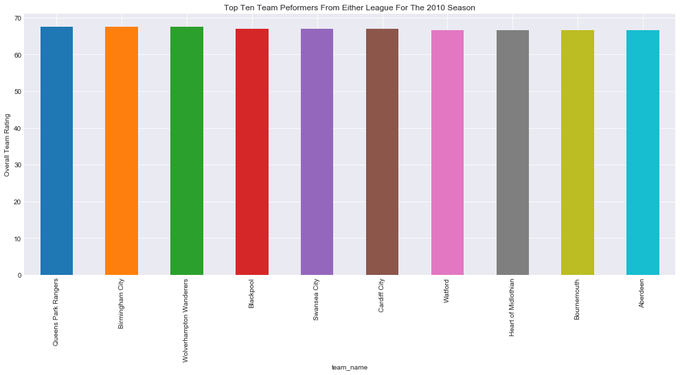

```python
# Creating a matplotlib.axes.AxesSubplot object
top_prf_2010_fig, ax = plt.subplots(figsize=(17,7))

# Setting the labels on my matplotlib object
ax.set_xlabel('Teams')
ax.set_ylabel('Overall Team Rating')

top_perf_2010_df['overall_team_rating'].plot(kind='bar',ax=ax,
                                       title="Top Ten Team Peformers From Either League For The 2010 Season",
                                       legend=False);
```

Ok. This result set is really throwing me for a loop. The top ten performing teams based on the algorithm overall team rating that I created has Queens Park Rangers, Birmingham City and Wolverhampton Wanderers as the top rated teams for 2010 with an overall team rating of 67.62. The next three teams, Blackpool, Swansea City and Cardiff City are deadlocked at an overall rating of 67.07. And lastly the final 4 teams, Watford, Heart of Midlothian, Bournemouth and Aberdeen all have a rating of 66.51. There isn't much variance in terms of overall team rating within this visualization at all.

However, given my knowledge of the game, I can start to hypothesize that maybe my approach and method to creating the algorithm might not be the best judge of overall team peformance because only a few of the teams present in this visualization, are actually in the Premier League in 2010. I would have to say the output I'm seeing may be based on the teams performance in the Championship, England's second division, as they either fought for in a playoff or earned promotion into the English Premier League which could and would warrant a high overall team rating. I'll have to make sure to check the league standings table to confirm this.

**Since I will be conducting a repetitive task in plotting the sliced data, I thought it would be more efficient to create a function to handle that task.**

```python
def tm_rtg_pltg_func(df, season):

    """
    Function's purpose is to plot the results of the data frame and season passed to it.

    Arguments:
        df - the specified data frame which is a slice of of the team rating data frame by season
        season(str) - the year in which the data is filtered by

    Returns:
    A plotted visualization of the specified data.
    """
    season = season

    title = "Top Ten Team Performers From Either League For the {} Season".format(season)

    # Creating a matplotlib.axes.AxesSubplot object
    df_fig, ax = plt.subplots(figsize=(17,7))

    # Setting the labels on my matplotlib object
    ax.set_xlabel('Teams')
    ax.set_ylabel('Overall Team Rating')

    df['overall_team_rating'].plot(kind='bar',ax=ax, title=title, legend=False);
```

```python
# using Pandas' query method to slice data frame by season
tm_rtg_2011_df = team_rating_df.query('season == "2011"')
```

```python
tm_rtg_2011_df = tm_rtg_2011_df.sort_values('overall_team_rating',ascending=0)
```

```python
# Selecting the top team performers from either leagues in 2010
top_perf_2011_df = tm_rtg_2011_df.head(10)

top_perf_2011_df.set_index('team_name', inplace=True)
```

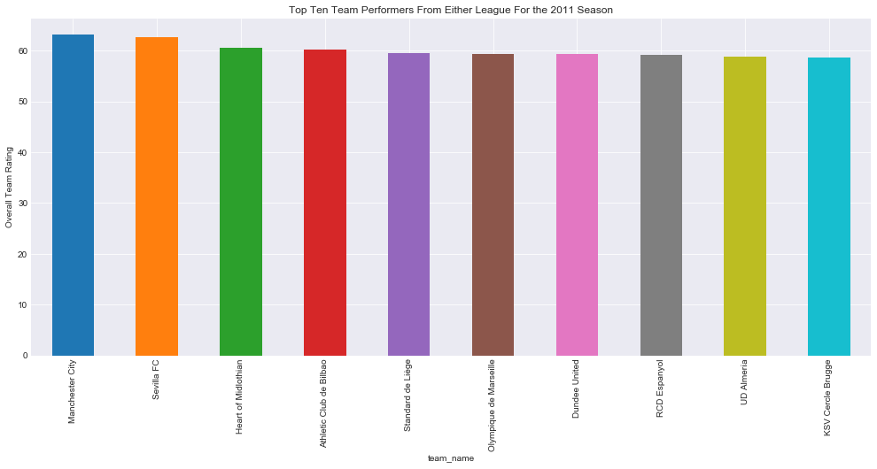

```python
tm_rtg_pltg_func(top_perf_2011_df, '2011')
```

Ok, this is a bit more reasurring. I know that Manchester City won the EPL in the 2011/12 season, so their overall team rating here of 63.18 makes sense. Okay, so maybe my algorithm (as generic as it is) might not be that bad in judging overall team performance based on the attributes and values associated with those attributes within the dataset.

I've noticed there is a lot more variance among overall team rating within this output, ranging from 63.18 to 58.73 for KSV Cercle Brugge of the Belgium Jupiler League. What is intersting to note here though, is that of the 10 top performing teams, 40% play in La Liga almost half. Now this could be a good argument that supports the notion of Spain's La Liga as the best league in the world. Belgium's Jupiler league is next in representation with 20% of the field boasting both Standard de Liege and KSV Cercle Brugge.

```python
# using Pandas' query method to slice data frame by season
tm_rtg_2012_df = team_rating_df.query('season == "2012"')
```

```python
tm_rtg_2012_df = tm_rtg_2012_df.sort_values('overall_team_rating',ascending=0)
```

```python
# Selecting the top team performers from either leagues in 2010
top_perf_2012_df = tm_rtg_2012_df.head(10)

top_perf_2012_df.set_index('team_name', inplace=True)
```

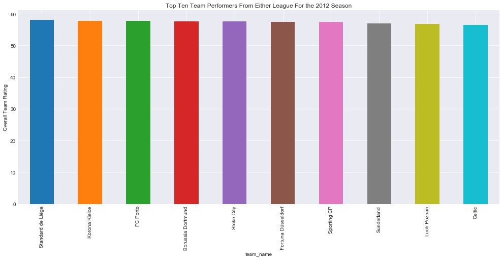

```python
tm_rtg_pltg_func(top_perf_2012_df, '2012')
```

```python
# using Pandas' query method to slice data frame by season
tm_rtg_2013_df = team_rating_df.query('season == "2013"')
```

```python
tm_rtg_2013_df = tm_rtg_2013_df.sort_values('overall_team_rating',ascending=0)
```

```python
# Selecting the top team performers from either leagues in 2010
top_perf_2013_df = tm_rtg_2013_df.head(10)

top_perf_2013_df.set_index('team_name', inplace=True)
```

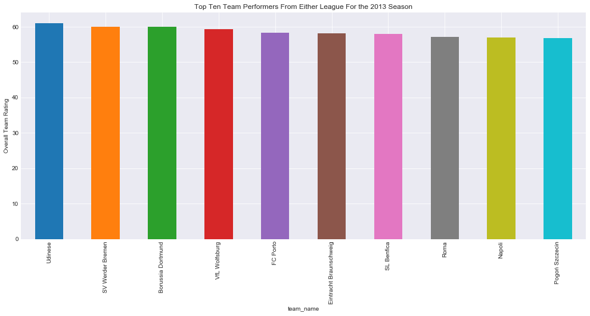

```python
tm_rtg_pltg_func(top_perf_2013_df, '2013')
```

Finally! A resulting table set that includes the Italian Serie A. Serie A has quite the representation in this result set, amassing 30% of the field, with Udinese as the top rated team in 2013 with an overall team rating of 60.96, AS Roma in 8th and Napoli in 9th with scores of 57.07 and 56.96 respectively.

The German Bundesliga, has a heavy influence on 2013's top rated teams boasting 40% of the field, with both SV Werder Bremen (the team with the oversized Volkswagon logo on the front of their jerseys) and Borussia Dortmund rated at 59.96 and positions second and third respectively. VfL Wolfsburg placing fourth with an overall team rating of 59.40. Portugal's Liga ZON Sagres is represented by FC Porto and SL Benfica, with overall team ratings of 58.29 and 57.96 respectively.

```python
# using Pandas' query method to slice data frame by season
tm_rtg_2014_df = team_rating_df.query('season == "2014"')
```

```python
tm_rtg_2014_df = tm_rtg_2014_df.sort_values('overall_team_rating',ascending=0)
```

```python
# Selecting the top team performers from either leagues in 2010
top_perf_2014_df = tm_rtg_2014_df.head(10)

top_perf_2014_df.set_index('team_name', inplace=True)
```

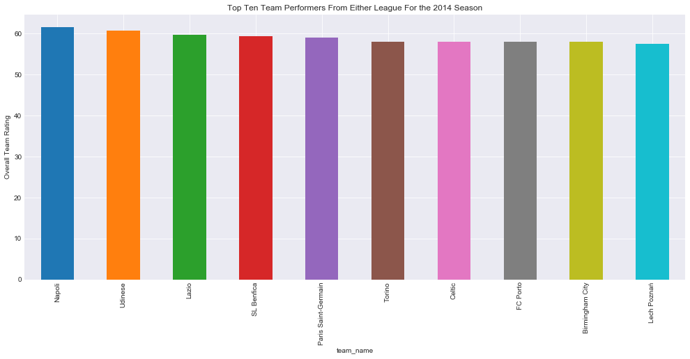

```python
tm_rtg_pltg_func(top_perf_2014_df, '2014')
```

In 2014 the Italian Serie A again having a strong showing with 40% of the field finishing within the top 6 for overall team rating. Napoli, drastically improving on their performance and form from the year before (could this this have anything to do with the acquisition of goal scoring machine Gonzalo Higuain from Real Madrid? ...he did join the club in 2013. If I have time, it would be interesting to see the variance in goals scored between those years of his arrival) Udinese, Lazio and Torino with overall team ratings of 61.56, 60.78, 59.78, and 58.11 respectively.

Portugal's Liga ZON Sagres is again represented by SL Benfica and FC Porto finishing 4th and 8th in overall team ratings with scores of 59.33 and 58.11 respectively.

```python
# using Pandas' query method to slice data frame by season
tm_rtg_2015_df = team_rating_df.query('season == "2015"')
```

```python
tm_rtg_2015_df = tm_rtg_2015_df.sort_values('overall_team_rating',ascending=0)
```

```python
# Selecting the top team performers from either leagues in 2010
top_perf_2015_df = tm_rtg_2015_df.head(10)

top_perf_2015_df.set_index('team_name', inplace=True)
```

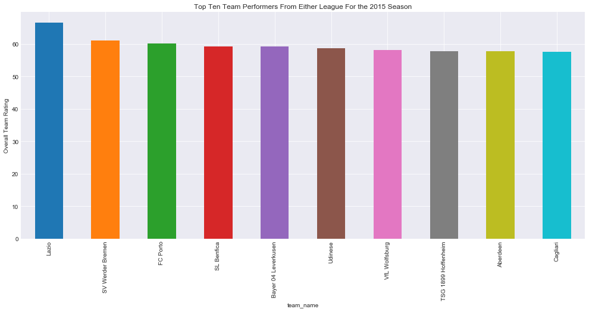

```python
tm_rtg_pltg_func(top_perf_2015_df, '2015')
```

Wow, the 2015 result set looks to be heavily German and Italian league influenced. Between both countries, they make up 70% of the top rated performing teams for 2015; Germany boasting 40% and Italy 30%. Portugal's Liga ZON Sagres holds down 40% of the top 5 performing teams, with FC Porto and SL Benfica finishing 3rd and 4th, with scores of 60.11 and 59.22 respectively.

Italian Serie A side, Lazio tops the group with a rating of 66.44, while fellow league counterparts Udinese and Cagliari finish 6th and 10th with scores of 58.67 and 57.44. Germany's Bundesliga representation of SV Werder Bremen, Bayer 04 Leverkusen, VfL Wolfsburg(who surprisingly made it to the quarter finals of the UEFA Champions League, and started out the first fixture defeating Real Madrid at home 2-0. They would eventually go on to lose the tie away in the 2nd leg in Madrid to Cristiano Ronaldo's hatrick.... surprise surprise.) and TSG 1899 Hoffenheim all scored 61.00, 59.11, 58.00, and 57.78 respectively.

With all these overall team ratings calculated and the top ten performers of each year, it would be interesting to see if these ratings transcends over to league performance and place in the standings.

**EXPLORING THE FIXTURE RESULTS DATASET**

```python
fixture_rslts_df.head()
```

|  | country | league | season | date | match_api_id | home_team_api_id | home_team | away_team_api_id | away_team | home_team_goal | away_team_goal | home_team_result | away_team_result |
| --- | --- | --- | --- | --- | --- | --- | --- | --- | --- | --- | --- | --- | --- |
| 0 | Belgium | Belgium Jupiler League | 2008/2009 | 2008-08-17 00:00:00 | 492473 | 9987 | KRC Genk | 9993 | Beerschot AC | 1 | 1 | 1 | 1 |
| 1 | Belgium | Belgium Jupiler League | 2008/2009 | 2008-08-16 00:00:00 | 492474 | 10000 | SV Zulte-Waregem | 9994 | Sporting Lokeren | 0 | 0 | 1 | 1 |
| 2 | Belgium | Belgium Jupiler League | 2008/2009 | 2008-08-16 00:00:00 | 492475 | 9984 | KSV Cercle Brugge | 8635 | RSC Anderlecht | 0 | 3 | 0 | 3 |
| 3 | Belgium | Belgium Jupiler League | 2008/2009 | 2008-08-17 00:00:00 | 492476 | 9991 | KAA Gent | 9998 | RAEC Mons | 5 | 0 | 3 | 0 |
| 4 | Belgium | Belgium Jupiler League | 2008/2009 | 2008-08-16 00:00:00 | 492477 | 7947 | FCV Dender EH | 9985 | Standard de Liège | 1 | 3 | 0 | 3 |

```python
# creating a data frame of my fixtures results dataset so as not to overwrite the original during my manipulations
fx_df = pd.DataFrame(fixture_rslts_df)
```

```python
# creating my conditions to filter my dataset by. I'll use these columns to help aggregate a league standings table
# for every league for every year within the dataset

# home_team
cond_1 = fx_df['home_team_result'] == 3
cond_2 = fx_df['home_team_result'] == 1
cond_3 = fx_df['home_team_result'] == 0

# away_team
cond_4 = fx_df['away_team_result'] == 3
cond_5 = fx_df['away_team_result'] == 1
cond_6 = fx_df['away_team_result'] == 0
```

```python
# grouping the fixture data by home team api id and aggregating the home team result column
# to retrieve total points earned at home.

# ill save the resulting table in a dataframe to work with shortly.

fix_hm_tm_totpts_df =  pd.DataFrame(fx_df.groupby(['league', 'season',
                                                   'home_team_api_id', 'home_team'])['home_team_result'].sum())
```

```python
# renaming home team result column to ' tot_hm_pts'
fix_hm_tm_totpts_df.rename(columns={'home_team_result': 'tot_hm_pts'}, inplace=True)
```

```python
# filtering the fixture data frame by condition 1 to create my home win pts total column
fix_hm_tm_totpts_df['hwpt_tot'] = fx_df[cond_1].groupby(['league', 'season',
                                                         'home_team_api_id', 'home_team'])['home_team_result'].sum()
```

```python
# filtering the fixture data frame by condition 2 to create my home draw pts total column
fix_hm_tm_totpts_df['hdpt_tot'] = fx_df[cond_2].groupby(['league', 'season','home_team_api_id',
                                                         'home_team'])['home_team_result'].sum()
```

```python
# filtering the fixture data frame by condition 3 to create my home loss total column
fix_hm_tm_totpts_df['hl_tot'] = fx_df[cond_3].groupby(['league', 'season','home_team_api_id',
                                                        'home_team'])['home_team_result'].count()
```

```python
# filtering the fixture data frame by league, season, home team api id and home team name, then summing the home team
# goals column to create my home goal total column which I'll use later to help aggregate goal differential
fix_hm_tm_totpts_df['hm_gl_tot'] = fx_df.groupby(['league', 'season', 'home_team_api_id',
                                                  'home_team'])['home_team_goal'].sum()
```

```python
# filtering the fixture data frame by league, season, home team api id and home team name, then summing the away team
# goals column to create my home goals conceded column which I'll use later to help aggregate goal differential
fix_hm_tm_totpts_df['hm_gl_cncd_tot'] = fx_df.groupby(['league', 'season',
                                                     'home_team_api_id', 'home_team'])['away_team_goal'].sum()
```

```python
# resetting index so I can rename the indexed column from home_team_api_id to team_api_id
fix_hm_tm_totpts_df.reset_index(inplace=True)
```

```python
fix_hm_tm_totpts_df.rename(columns={'home_team_api_id': 'team_api_id'}, inplace=True)
```

```python
fix_hm_tm_totpts_df.rename(columns={'home_team':'team_name'}, inplace=True)
```

```python
# replacing the NaN/Null value in home draw point total for Standard Liege because they did not draw any matches at
# home.
fix_hm_tm_totpts_df.fillna(0, inplace=True)
```

```python
# grouping the fixture data by away team api id and aggregating the away team result column
# to retrieve total points earned away from home.

# ill save the resulting table in a dataframe to work with shortly.

fix_awy_tm_totpts_df =  pd.DataFrame(fx_df.groupby(['league', 'season',
                                                   'away_team_api_id', 'away_team'])['away_team_result'].sum())
```

```python
# renaming away team result column to ' tot_awy_pts'
fix_awy_tm_totpts_df.rename(columns={'away_team_result': 'tot_awy_pts'}, inplace=True)
```

```python
# filtering the fixture data frame by condition 4 to create my away win pts total column
fix_awy_tm_totpts_df['awy_wpt_tot'] = fx_df[cond_4].groupby(['league', 'season', 'away_team_api_id',
                                                             'away_team'])['away_team_result'].sum()
```

```python
# filtering the fixture data frame by condition 5 to create my away draw pts total column
fix_awy_tm_totpts_df['awy_dpt_tot'] = fx_df[cond_5].groupby(['league', 'season','away_team_api_id',
                                                             'away_team'])['away_team_result'].sum()
```

```python
# filtering the fixture data frame by condition 6 to create my away loss total column
fix_awy_tm_totpts_df['awy_lss_tot'] = fx_df[cond_6].groupby(['league', 'season','away_team_api_id',
                                                             'away_team'])['away_team_result'].count()
```

```python
# filtering the fixture data frame by league, season, away team api id and away team name, then summing the away team
# goals column to create my away goal total column which I'll use later to help aggregate goal differential
fix_awy_tm_totpts_df['awy_gl_tot'] = fx_df.groupby(['league', 'season', 'away_team_api_id',
                                                    'away_team'])['away_team_goal'].sum()
```

```python
# filtering the fixture data frame by league, season, away team api id and away team name, then summing the home team
# goals column to create my away goals conceded column which I'll use later to help aggregate goal differential
fix_awy_tm_totpts_df['awy_gl_cncd_tot'] = fx_df.groupby(['league', 'season',
                                                         'away_team_api_id', 'away_team'])['home_team_goal'].sum()
```

```python
# resetting index so I can rename the indexed column from away_team_api_id to team_api_id
fix_awy_tm_totpts_df.reset_index(inplace=True)
```

```python
fix_awy_tm_totpts_df.rename(columns={'away_team_api_id': 'team_api_id'}, inplace=True)
```

```python
fix_awy_tm_totpts_df.rename(columns={'away_team':'team_name'}, inplace=True)
```

```python
fix_awy_tm_totpts_df.fillna(0, inplace=True)
```

```python
# tweaking my data frames to get them ready for concatenation by setting similar indexes in both data frames
fix_hm_tm_totpts_df.set_index(['league', 'season', 'team_api_id', 'team_name'], inplace=True)

fix_awy_tm_totpts_df.set_index(['league', 'season', 'team_api_id', 'team_name'], inplace=True)
```

```python
# combining my home/away team total points dfs to create a league standings table for every league and
# season within the entire dataset
frames = [fix_hm_tm_totpts_df, fix_awy_tm_totpts_df]

lg_stdgs_df = pd.concat(frames, axis=1, join='outer')
```

```python
# creating my 'GP', games played column for each season/league
lg_stdgs_df['GP'] = (((lg_stdgs_df['hwpt_tot'] + lg_stdgs_df['awy_wpt_tot']) / 3) +
                     (lg_stdgs_df['hdpt_tot'] + lg_stdgs_df['awy_dpt_tot']) +
                     (lg_stdgs_df['hl_tot'] + lg_stdgs_df['awy_lss_tot']))
```

```python
# creating my 'W', wins column for each team/league/season
lg_stdgs_df['W'] = ((lg_stdgs_df['hwpt_tot'] + lg_stdgs_df['awy_wpt_tot']) / 3)
```

```python
# creating my 'D', draws column for each team/league/season
lg_stdgs_df['D'] = (lg_stdgs_df['hdpt_tot'] + lg_stdgs_df['awy_dpt_tot'])
```

```python
# creating my 'L', losses column for each team/league/season
lg_stdgs_df['L'] = (lg_stdgs_df['hl_tot'] + lg_stdgs_df['awy_lss_tot'])
```

```python
# creating my 'GF', goals for column for each team/league/season
lg_stdgs_df['GF'] = (lg_stdgs_df['hm_gl_tot'] + lg_stdgs_df['awy_gl_tot'])
```

```python
# creating my 'GA', goals against column for each team/league/season
lg_stdgs_df['GA'] = (lg_stdgs_df['hm_gl_cncd_tot'] + lg_stdgs_df['awy_gl_cncd_tot'])
```

```python
# creating my 'GD', goal differential column for each team/league/season
lg_stdgs_df['GD'] = (lg_stdgs_df['GF'] - lg_stdgs_df['GA'])
```

```python
# creating my 'Tot_Pts', total points column for each team/league/season
lg_stdgs_df['Tot_Pts'] = (lg_stdgs_df['tot_hm_pts'] + lg_stdgs_df['tot_awy_pts'])
```

```python
# creating a function to order my data frame columns
def column_order(frame, var):
    """
    Function used to order the data frame columns

    Returns:
    Based on the selected list of columns, function returns the preferred order list of columns specified.
    """
    if type(var) is str:
        var = [var] # let the command take a string or list

    varlist = [w for w in frame.columns if w not in var]
    frame = frame[var + varlist]

    return frame
```

```python
lg_stdgs_df = column_order(lg_stdgs_df, ['GP', 'W', 'D', 'L', 'GF', 'GA', 'GD', 'Tot_Pts'])
```

```python
# querying the league standings table by season
sn_0809_lg_stdgs_vw = lg_stdgs_df.query('season == "2008/2009"')
```

```python
# querying the season 2008/2009 league standings view by league to make plotting easier
esp_sn_0809_lg_stdgs = sn_0809_lg_stdgs_vw.query('league == "Spain LIGA BBVA"')
```

```python
# sorting Spain's La Liga League Standings table in descending order by total points
esp_sn_0809_lg_stdgs = esp_sn_0809_lg_stdgs.sort_values('Tot_Pts', ascending=0)
```

```python
esp_sn_0809_lg_stdgs.reset_index(inplace=True)
```

```python
esp_sn_0809_lg_stdgs.set_index(['league', 'season', 'team_api_id', 'team_name'], inplace=True)
```

```python
# I'll only do this once to save space in the report, but this is what the league standings tables will look like when
# filtered by league, season and indexed by 'team_name'
esp_sn_0809_lg_stdgs
```

| league | season | team_api_id | team_name | GP | W | D | L | GF | GA | GD | Tot_Pts | tot_hm_pts | hwpt_tot | hdpt_tot | hl_tot | hm_gl_tot | hm_gl_cncd_tot | tot_awy_pts | awy_wpt_tot | awy_dpt_tot | awy_lss_tot | awy_gl_tot | awy_gl_cncd_tot |
| --- | --- | --- | --- | --- | --- | --- | --- | --- | --- | --- | --- | --- | --- | --- | --- | --- | --- | --- | --- | --- | --- | --- | --- |
| Spain LIGA BBVA | 2008/2009 | 8634 | FC Barcelona | 38.0 | 27.0 | 6.0 | 5.0 | 105 | 35 | 70 | 87 | 45 | 42.0 | 3.0 | 2.0 | 61 | 14 | 42 | 39.0 | 3.0 | 3.0 | 44 | 21 |
|  |  | 8633 | Real Madrid CF | 38.0 | 25.0 | 3.0 | 10.0 | 83 | 52 | 31 | 78 | 44 | 42.0 | 2.0 | 3.0 | 49 | 29 | 34 | 33.0 | 1.0 | 7.0 | 34 | 23 |
|  |  | 8302 | Sevilla FC | 38.0 | 21.0 | 7.0 | 10.0 | 54 | 39 | 15 | 70 | 35 | 33.0 | 2.0 | 6.0 | 28 | 20 | 35 | 30.0 | 5.0 | 4.0 | 26 | 19 |
|  |  | 9906 | Atlético Madrid | 38.0 | 20.0 | 7.0 | 11.0 | 80 | 57 | 23 | 67 | 40 | 39.0 | 1.0 | 5.0 | 47 | 23 | 27 | 21.0 | 6.0 | 6.0 | 33 | 34 |
|  |  | 10205 | Villarreal CF | 38.0 | 18.0 | 11.0 | 9.0 | 61 | 54 | 7 | 65 | 39 | 36.0 | 3.0 | 4.0 | 33 | 25 | 26 | 18.0 | 8.0 | 5.0 | 28 | 29 |
|  |  | 10267 | Valencia CF | 38.0 | 18.0 | 8.0 | 12.0 | 68 | 54 | 14 | 62 | 40 | 36.0 | 4.0 | 3.0 | 47 | 26 | 22 | 18.0 | 4.0 | 9.0 | 21 | 28 |
|  |  | 9783 | RC Deportivo de La Coruña | 38.0 | 16.0 | 10.0 | 12.0 | 48 | 47 | 1 | 58 | 36 | 30.0 | 6.0 | 3.0 | 30 | 18 | 22 | 18.0 | 4.0 | 9.0 | 18 | 29 |
|  |  | 9864 | Málaga CF | 38.0 | 15.0 | 10.0 | 13.0 | 55 | 59 | -4 | 55 | 31 | 24.0 | 7.0 | 4.0 | 28 | 23 | 24 | 21.0 | 3.0 | 9.0 | 27 | 36 |
|  |  | 8661 | RCD Mallorca | 38.0 | 14.0 | 9.0 | 15.0 | 53 | 60 | -7 | 51 | 33 | 27.0 | 6.0 | 4.0 | 33 | 24 | 18 | 15.0 | 3.0 | 11.0 | 20 | 36 |
|  |  | 8558 | RCD Espanyol | 38.0 | 12.0 | 11.0 | 15.0 | 46 | 49 | -3 | 47 | 29 | 24.0 | 5.0 | 6.0 | 28 | 22 | 18 | 12.0 | 6.0 | 9.0 | 18 | 27 |
|  |  | 8696 | Racing Santander | 38.0 | 12.0 | 10.0 | 16.0 | 49 | 48 | 1 | 46 | 23 | 15.0 | 8.0 | 6.0 | 28 | 22 | 23 | 21.0 | 2.0 | 10.0 | 21 | 26 |
|  |  | 9865 | UD Almería | 38.0 | 13.0 | 7.0 | 18.0 | 45 | 61 | -16 | 46 | 37 | 33.0 | 4.0 | 4.0 | 27 | 20 | 9 | 6.0 | 3.0 | 14.0 | 18 | 41 |
|  |  | 8315 | Athletic Club de Bilbao | 38.0 | 12.0 | 8.0 | 18.0 | 47 | 62 | -15 | 44 | 29 | 27.0 | 2.0 | 8.0 | 28 | 29 | 15 | 9.0 | 6.0 | 10.0 | 19 | 33 |
|  |  | 9869 | Real Sporting de Gijón | 38.0 | 14.0 | 1.0 | 23.0 | 47 | 79 | -32 | 43 | 25 | 24.0 | 1.0 | 10.0 | 24 | 37 | 18 | 18.0 | 0.0 | 13.0 | 23 | 42 |
|  |  | 8371 | CA Osasuna | 38.0 | 10.0 | 13.0 | 15.0 | 41 | 47 | -6 | 43 | 29 | 24.0 | 5.0 | 6.0 | 27 | 22 | 14 | 6.0 | 8.0 | 9.0 | 14 | 25 |
|  |  | 10281 | Real Valladolid | 38.0 | 12.0 | 7.0 | 19.0 | 46 | 58 | -12 | 43 | 29 | 24.0 | 5.0 | 6.0 | 22 | 17 | 14 | 12.0 | 2.0 | 13.0 | 24 | 41 |
|  |  | 8603 | Real Betis Balompié | 38.0 | 10.0 | 12.0 | 16.0 | 51 | 58 | -7 | 42 | 20 | 12.0 | 8.0 | 7.0 | 24 | 25 | 22 | 18.0 | 4.0 | 9.0 | 27 | 33 |
|  |  | 8305 | Getafe CF | 38.0 | 10.0 | 12.0 | 16.0 | 50 | 56 | -6 | 42 | 25 | 21.0 | 4.0 | 8.0 | 27 | 23 | 17 | 9.0 | 8.0 | 8.0 | 23 | 33 |
|  |  | 8388 | CD Numancia | 38.0 | 10.0 | 5.0 | 23.0 | 38 | 69 | -31 | 35 | 30 | 27.0 | 3.0 | 7.0 | 23 | 22 | 5 | 3.0 | 2.0 | 16.0 | 15 | 47 |
|  |  | 8479 | RC Recreativo | 38.0 | 8.0 | 9.0 | 21.0 | 34 | 57 | -23 | 33 | 16 | 12.0 | 4.0 | 11.0 | 17 | 29 | 17 | 12.0 | 5.0 | 10.0 | 17 | 28 |

```python
esp_sn_0809_lg_stdgs.describe()
```

|  | GP | W | D | L | GF | GA | GD | Tot_Pts | tot_hm_pts | hwpt_tot | hdpt_tot | hl_tot | hm_gl_tot | hm_gl_cncd_tot | tot_awy_pts | awy_wpt_tot | awy_dpt_tot | awy_lss_tot | awy_gl_tot | awy_gl_cncd_tot |
| --- | --- | --- | --- | --- | --- | --- | --- | --- | --- | --- | --- | --- | --- | --- | --- | --- | --- | --- | --- | --- |
| count | 20.0 | 20.000000 | 20.000000 | 20.000000 | 20.000000 | 20.000000 | 20.00000 | 20.000000 | 20.000000 | 20.000000 | 20.000000 | 20.000000 | 20.000000 | 20.00000 | 20.000000 | 20.000000 | 20.000000 | 20.000000 | 20.000000 | 20.000000 |
| mean | 38.0 | 14.850000 | 8.300000 | 14.850000 | 55.050000 | 55.050000 | 0.00000 | 52.850000 | 31.750000 | 27.600000 | 4.150000 | 5.650000 | 31.550000 | 23.50000 | 21.100000 | 16.950000 | 4.150000 | 9.200000 | 23.500000 | 31.550000 |
| std | 0.0 | 5.203996 | 3.062507 | 4.727022 | 17.107939 | 9.746659 | 23.16531 | 14.517775 | 7.812776 | 8.899438 | 2.109502 | 2.390221 | 10.932689 | 5.03148 | 8.813268 | 9.196538 | 2.323224 | 3.270281 | 7.301766 | 7.444355 |
| min | 38.0 | 8.000000 | 1.000000 | 5.000000 | 34.000000 | 35.000000 | -32.00000 | 33.000000 | 16.000000 | 12.000000 | 1.000000 | 2.000000 | 17.000000 | 14.00000 | 5.000000 | 3.000000 | 0.000000 | 3.000000 | 14.000000 | 19.000000 |
| 25% | 38.0 | 11.500000 | 7.000000 | 11.750000 | 46.000000 | 48.750000 | -12.75000 | 43.000000 | 28.000000 | 24.000000 | 2.750000 | 4.000000 | 26.250000 | 21.50000 | 16.500000 | 11.250000 | 2.750000 | 7.750000 | 18.000000 | 26.750000 |
| 50% | 38.0 | 13.500000 | 8.500000 | 15.000000 | 49.500000 | 56.500000 | -5.00000 | 46.500000 | 30.500000 | 27.000000 | 4.000000 | 6.000000 | 28.000000 | 23.00000 | 20.000000 | 18.000000 | 4.000000 | 9.000000 | 22.000000 | 31.000000 |
| 75% | 38.0 | 18.000000 | 10.250000 | 18.000000 | 56.500000 | 59.250000 | 8.75000 | 62.750000 | 37.500000 | 33.750000 | 5.250000 | 7.000000 | 33.000000 | 25.25000 | 24.500000 | 21.000000 | 6.000000 | 10.250000 | 27.000000 | 36.000000 |
| max | 38.0 | 27.000000 | 13.000000 | 23.000000 | 105.000000 | 79.000000 | 70.00000 | 87.000000 | 45.000000 | 42.000000 | 8.000000 | 11.000000 | 61.000000 | 37.00000 | 42.000000 | 39.000000 | 8.000000 | 16.000000 | 44.000000 | 47.000000 |

```python
# resetting my index so my plot looks cleaner
esp_sn_0809_lg_stdgs.reset_index(inplace=True)

esp_sn_0809_lg_stdgs.set_index('team_name', inplace=True)
```

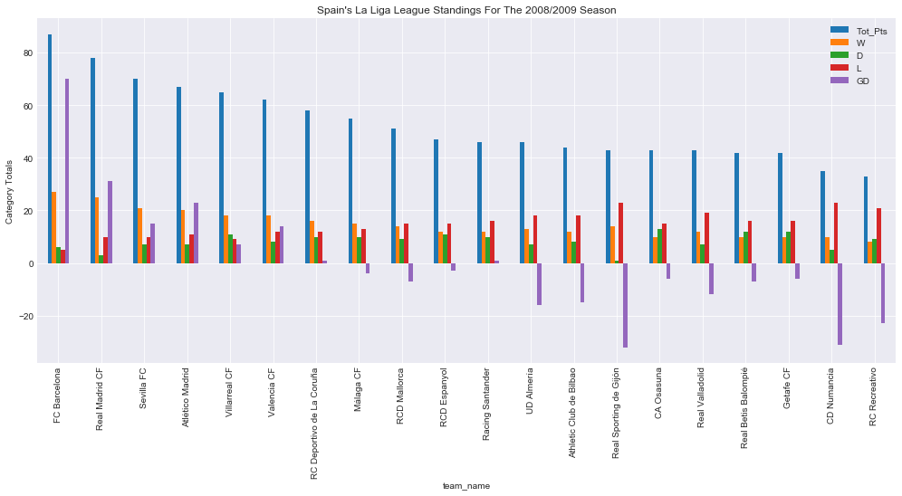

```python
# Creating a matplotlib.axes.AxesSubplot object
esp_fig, ax = plt.subplots(figsize=(17,7))

# Setting the labels on my matplotlib object
ax.set_xlabel('Teams')
ax.set_ylabel('Category Totals')

esp_sn_0809_lg_stdgs[['Tot_Pts', 'W', 'D', 'L', 'GD']].plot(kind='bar',ax=ax,
                                       title="Spain's La Liga League Standings For The 2008/2009 Season",
                                       legend=True);
```

**Plotting the English Premier League Table Standings for the 2008/2009 Season**

```python
# querying the season 2008/2009 league standings view by league to make plotting easier
eng_sn_0809_lg_stdgs = sn_0809_lg_stdgs_vw.query('league == "England Premier League"')
```

```python
eng_sn_0809_lg_stdgs = eng_sn_0809_lg_stdgs.sort_values('Tot_Pts', ascending=0)
```

```python
eng_sn_0809_lg_stdgs.reset_index(inplace=True)
```

```python
np.array(eng_sn_0809_lg_stdgs['team_name'])
```

```
array(['Manchester United', 'Liverpool', 'Chelsea', 'Arsenal', 'Everton',
       'Aston Villa', 'Fulham', 'Tottenham Hotspur', 'West Ham United',
       'Manchester City', 'Wigan Athletic', 'Stoke City',
       'Blackburn Rovers', 'Bolton Wanderers', 'Portsmouth', 'Sunderland',
       'Hull City', 'Newcastle United', 'West Bromwich Albion',
       'Middlesbrough'], dtype=object)
```

```python
eng_sn_0809_lg_stdgs.describe()
```

|  | team_api_id | GP | W | D | L | GF | GA | GD | Tot_Pts | tot_hm_pts | ... | hdpt_tot | hl_tot | hm_gl_tot | hm_gl_cncd_tot | tot_awy_pts | awy_wpt_tot | awy_dpt_tot | awy_lss_tot | awy_gl_tot | awy_gl_cncd_tot |
| --- | --- | --- | --- | --- | --- | --- | --- | --- | --- | --- | --- | --- | --- | --- | --- | --- | --- | --- | --- | --- | --- |
| count | 20.000000 | 20.0 | 20.000000 | 20.00000 | 20.000000 | 20.000000 | 20.000000 | 20.000000 | 20.000000 | 20.000000 | ... | 20.000000 | 20.000000 | 20.000000 | 20.000000 | 20.000000 | 20.000000 | 20.000000 | 20.000000 | 20.000000 | 20.000000 |
| mean | 9034.550000 | 38.0 | 14.150000 | 9.70000 | 14.150000 | 47.100000 | 47.100000 | 0.000000 | 52.150000 | 30.800000 | ... | 4.850000 | 5.500000 | 26.600000 | 20.500000 | 21.350000 | 16.500000 | 4.850000 | 8.650000 | 20.500000 | 26.600000 |
| std | 734.565355 | 0.0 | 6.226218 | 2.05452 | 6.011174 | 14.010898 | 12.977308 | 25.437229 | 18.236098 | 8.563079 | ... | 2.345769 | 2.910959 | 7.789331 | 7.067345 | 11.828934 | 12.292488 | 1.871532 | 3.923948 | 8.262152 | 8.665722 |
| min | 8455.000000 | 38.0 | 7.000000 | 5.00000 | 2.000000 | 28.000000 | 24.000000 | -31.000000 | 32.000000 | 14.000000 | ... | 0.000000 | 0.000000 | 17.000000 | 10.000000 | 8.000000 | 3.000000 | 2.000000 | 2.000000 | 10.000000 | 11.000000 |
| 25% | 8543.750000 | 38.0 | 9.750000 | 8.75000 | 9.750000 | 38.000000 | 37.000000 | -19.250000 | 39.750000 | 24.750000 | ... | 3.000000 | 3.750000 | 21.000000 | 15.750000 | 13.500000 | 6.000000 | 4.000000 | 6.250000 | 15.250000 | 20.250000 |
| 50% | 8654.500000 | 38.0 | 13.000000 | 10.00000 | 17.000000 | 40.500000 | 49.000000 | -7.000000 | 47.500000 | 29.500000 | ... | 5.000000 | 5.500000 | 25.000000 | 20.000000 | 16.000000 | 12.000000 | 4.500000 | 9.500000 | 18.500000 | 28.000000 |
| 75% | 9838.500000 | 38.0 | 17.000000 | 11.00000 | 18.250000 | 55.750000 | 57.000000 | 10.500000 | 62.250000 | 36.500000 | ... | 6.250000 | 7.250000 | 31.000000 | 23.500000 | 32.250000 | 27.000000 | 6.000000 | 11.250000 | 24.250000 | 32.500000 |
| max | 10261.000000 | 38.0 | 28.000000 | 13.00000 | 22.000000 | 77.000000 | 67.000000 | 50.000000 | 90.000000 | 50.000000 | ... | 9.000000 | 11.000000 | 43.000000 | 36.000000 | 44.000000 | 42.000000 | 8.000000 | 15.000000 | 37.000000 | 40.000000 |

8 rows × 21 columns

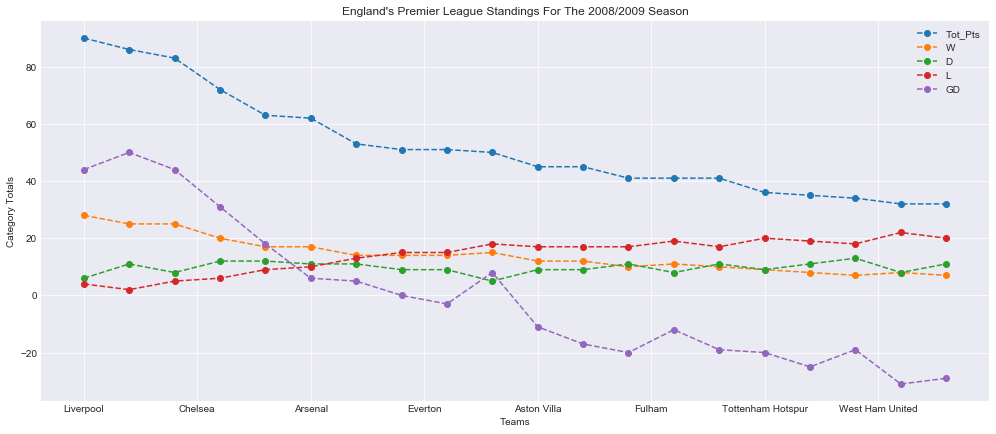

```python
# Setting my labels for the graph
labels = list(eng_sn_0809_lg_stdgs['team_name'])

# Creating a matplotlib.axes.AxesSubplot object
eng_fig, ax = plt.subplots(figsize=(17,7))

# Setting the labels on my matplotlib object
ax.set_xticklabels(labels)
ax.set_xlabel('Teams')
ax.set_ylabel('Category Totals')

eng_sn_0809_lg_stdgs[['Tot_Pts', 'W', 'D', 'L', 'GD']].plot(kind='line',ax=ax,
                                       title="England's Premier League Standings For The 2008/2009 Season",
                                       legend=True, style='--', marker='o');
```

**Plotting the Italian Serie A League Table Standings for the 2008/2009 Season**

```python
# querying the season 2008/2009 league standings view by league to make plotting easier
ita_sn_0809_lg_stdgs = sn_0809_lg_stdgs_vw.query('league == "Italy Serie A"')
```

```python
ita_sn_0809_lg_stdgs = ita_sn_0809_lg_stdgs.sort_values('Tot_Pts', ascending=0)
```

```python
ita_sn_0809_lg_stdgs.reset_index(inplace=True)
```

```python
ita_sn_0809_lg_stdgs.set_index('team_name', inplace=True)
```

```python
ita_sn_0809_lg_stdgs.describe()
```

|  | team_api_id | GP | W | D | L | GF | GA | GD | Tot_Pts | tot_hm_pts | ... | hdpt_tot | hl_tot | hm_gl_tot | hm_gl_cncd_tot | tot_awy_pts | awy_wpt_tot | awy_dpt_tot | awy_lss_tot | awy_gl_tot | awy_gl_cncd_tot |
| --- | --- | --- | --- | --- | --- | --- | --- | --- | --- | --- | --- | --- | --- | --- | --- | --- | --- | --- | --- | --- | --- |
| count | 20.00000 | 20.0 | 20.000000 | 20.000000 | 20.000000 | 20.000000 | 20.00000 | 20.000000 | 20.000000 | 20.000000 | ... | 20.000000 | 20.000000 | 20.000000 | 20.000000 | 20.000000 | 20.000000 | 20.000000 | 20.000000 | 20.000000 | 20.000000 |
| mean | 9044.25000 | 38.0 | 14.250000 | 9.500000 | 14.250000 | 49.400000 | 49.40000 | 0.000000 | 52.250000 | 33.550000 | ... | 4.750000 | 4.650000 | 28.900000 | 20.500000 | 18.700000 | 13.950000 | 4.750000 | 9.600000 | 20.500000 | 28.900000 |
| std | 664.12902 | 0.0 | 5.627704 | 2.800376 | 4.755883 | 12.646614 | 9.97576 | 20.219844 | 15.562692 | 9.495013 | ... | 2.468219 | 2.621269 | 7.972981 | 5.296474 | 8.234076 | 8.556161 | 1.332785 | 2.741494 | 6.809436 | 6.640387 |
| min | 8524.00000 | 38.0 | 5.000000 | 5.000000 | 4.000000 | 30.000000 | 32.00000 | -32.000000 | 30.000000 | 17.000000 | ... | 1.000000 | 0.000000 | 15.000000 | 12.000000 | 9.000000 | 3.000000 | 1.000000 | 4.000000 | 7.000000 | 16.000000 |
| 25% | 8538.75000 | 38.0 | 10.500000 | 8.000000 | 11.750000 | 40.000000 | 42.75000 | -11.750000 | 41.750000 | 27.250000 | ... | 3.000000 | 2.750000 | 23.000000 | 16.750000 | 12.750000 | 9.000000 | 4.000000 | 8.750000 | 16.000000 | 24.750000 |
| 50% | 8618.00000 | 38.0 | 14.000000 | 9.500000 | 15.500000 | 47.500000 | 50.00000 | -2.500000 | 48.500000 | 34.500000 | ... | 4.500000 | 4.000000 | 27.500000 | 20.000000 | 16.000000 | 10.500000 | 5.000000 | 11.000000 | 17.000000 | 30.000000 |
| 75% | 9861.50000 | 38.0 | 18.250000 | 11.000000 | 18.000000 | 58.000000 | 56.50000 | 12.000000 | 64.250000 | 41.500000 | ... | 5.250000 | 7.000000 | 36.250000 | 24.250000 | 22.500000 | 21.000000 | 5.250000 | 12.000000 | 25.000000 | 32.750000 |
| max | 10233.00000 | 38.0 | 25.000000 | 15.000000 | 20.000000 | 70.000000 | 67.00000 | 38.000000 | 84.000000 | 47.000000 | ... | 10.000000 | 10.000000 | 42.000000 | 31.000000 | 37.000000 | 33.000000 | 7.000000 | 13.000000 | 33.000000 | 39.000000 |

8 rows × 21 columns

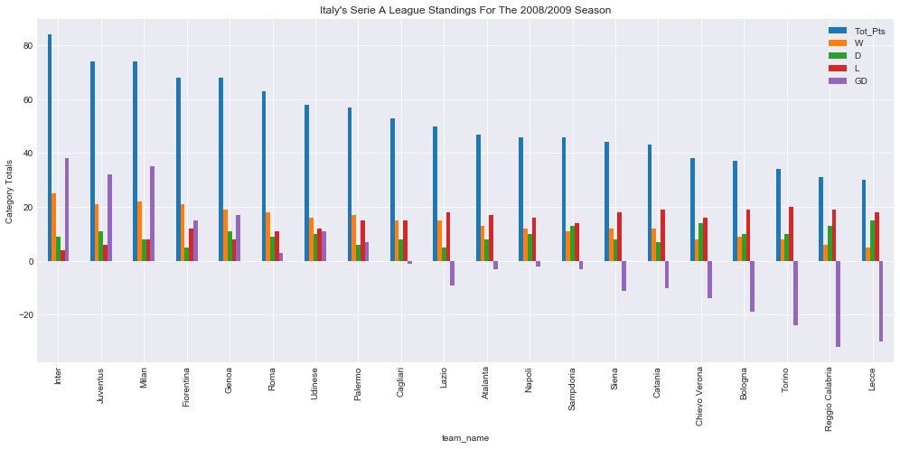

```python
# Creating a matplotlib.axes.AxesSubplot object
ita_fig, ax = plt.subplots(figsize=(17,7))

# Setting the labels on my matplotlib object
ax.set_xlabel('Teams')
ax.set_ylabel('Category Totals')

ita_sn_0809_lg_stdgs[['Tot_Pts', 'W', 'D', 'L', 'GD']].plot(kind='bar',ax=ax,
                                       title="Italy's Serie A League Standings For The 2008/2009 Season",
                                       legend=True);
```

# Conclusions:

This was a challenging but rewarding project. The purpose of my exploration was to see if I could use the available European Soccer dataset to analytically investigate and possibly answer(while making a few observations along the way) a long standing debate between futbol(soccer) fans:

1.) The 'Age Old Question' among soccer(futbol) fanatics around the globle: **Which country has the better league?**

Because this is a highly subjective topic to analyze and report on, I thought it would be cool to tackle answering this question from 3 different perspectives, giving my analysis an wholistic approach:

1.) Comparing the **goals scored and goals conceded** among leagues and teams filtered by season

2.) Comparing **team attributes vs. performance**

3.) Comparing **player attributes/team vs. peformance**

Well, firstly I will never concede and admit that I might have bitten off more than I can chew by attempting to investigate this dataset. However, given its size, and the sheer volume of data the set contains, I fear my report has merely touched/skipped the surface of what lies beneath with regards to insight into league, and team peformances per season.

For my investigation I was able to tackle the total goals, team attributes, and fixture results data frames respectively. Here is a summation of those explorations:

**Team Attributes Data Frame:**

This subset of data provided some interesting observations as well. Based on the total goal results for each league, I was expecting to see a relatively even distribution of teams from each of the top 3 peforming leagues, but that didnt seem to be the case. I at first started to question whether my generic algorithm to calculate overall team rating was sufficient enough to categorically rate each team on par with the given team ratings contained within the original data set, the team attributes table. The 2010 season had Queens Park Rangers as the top peforming team in terms of overall rating but my concerns were alleviated when 2011's season top performers produced Manchester City, as the top performing team that season. They also won the EPL that year which makes sense for their rating, as the EPL is arguably one if not the most physically demanding league in Europe. Through further investigation, it just so happens that 40% of the top ten performers that year also play in Spain's La Liga, with Sevilla FC coming in right behind Manchester City, Athletic Club de Bilbao, RCD Espanyol and UD Almeria. The 2012 season had two representatives from the top 3 leagues, with Stoke City and Sunderland(EPL) peforming in the middle and tail end of the pack. Finally, we get some heavy Italian Serie A and German Bundesliga representation for the 2013 season of top performers with 70% of the field. The 2014 season saw top peformer Italy's Serie A side, Napoli, jump 8 spots to top the top performers for 2014. I might have implied this jump was due to the signing of goal scoring machine Gonzalo Higuain from Real Madrid but it's all conjecture at this point. And lasty, the 2015 season saw another heavy German and Italian representation with 70% of the field.

On that note, given my knowledge of the game, I would have expected to see more well know clubs that perform consistently, year in and year out, having great domestic campaigns as well as faring well in European competitions. Here are a few teams I would have expected to see but didnt: FC Barcelona | Real Madrid FC | Manchester United | Chelsea FC | Aresenal FC | Atletico de Madrid (whose had fantastic European campaigns over the last 5 years) | Juventus and others.

Further analysis, I hope, into the data set will help to explain some of these results. But the more I think about it and view the data, I'm starting to think my algorithm to determine overall team rating, is just a little to rudimentary, and needs to be beefed up a bit.... taking into account player attributes within the team, as well as the team attributes themselves. Further exploration is definitely needed here.

**Fixture Results Data Frame:**

I had the most fun with this dataset. Manipulating and plotting really presented a challenge but I think I was able to effectively compare multiple variables for each team based on the season selected. Being that I am somewhat familiar with the league finishes of some clubs, it was interesting to see how their stats matched up against one another, specifically total points, wins, draws, losses, goals for and against/conceded. There's still so much more data to explore. As expected however, were the finishes of the top teams in each of the three leagues I decided to plot. For Spain's La Liga, FC Barcelona, Real Madrid CF, and Sevilla FC, England's Premier League, Manchester United, Liverpool FC and Chelsea FC, and for the Italian Serie A, FC Inter Milan, Juventus and AC Milan.

What I did find interesting however, was that for each league more than half of the field of teams had a negative goal differential by the end of the season. With my understanding of the game and leagues, most teams that fall between 7th and 15th places in the league standings consistently are really quite similar. These are usually always the more fun games to watch. There may not be any superstars, or flashy skills, tricks and flare, but they play the game with passion, verve, and tactical discipline. It's clearly evident in the ways these types of matches progress, you can see each team fighting for their existence to remain in the top division -- whereas with some of these other big name clubs with superstars, winning is almost expected. In my opinion, this ruins the spontanaeity of the game. It makes for a better match in terms of end to end action, but for me, like I said before, the game is meant to be played with freedom, creativity and ingenuity, so I enjoy the flare.

## Resources:

Here are list of resources used to complete this project:

1. Udacity's Project 3, Investigate a Data set lessons
2. Udemy online learning platform: Python Masterclass with Tim Buchalka
3. Udemy online learning platform: Data Analysis and Visualization with Jose Portilla
4. Python Crash course by Eric Matthes
5. Google/StackOverflow